# CS 5324 Lab 7: Recurrent Neural Network

For this assignment, we will be exploring the [IMDB Movie Reviews](https://www.kaggle.com/datasets/lakshmi25npathi/imdb-dataset-of-50k-movie-reviews) dataset. This dataset is composed of observations regarding movie reviews with either a positive or negative sentiment.

This dataset was sourced from [Kaggle](https://www.kaggle.com/dsets) and consists of around 50,000 observations.

## Team

The team consists of four members:

1. Samina Faheem
2. Yohan Chari
3. Giancarlos Dominguez
4. Samuel Kevetter

## Data Preparation

### Defining the Dataset

```python
import subprocess
import platform
import os
import itertools
import time
import pickle
import re
import random
from IPython.display import display, HTML, Markdown, clear_output

import pandas as pd
import numpy as np
import matplotlib.pyplot as plt
import matplotlib
import seaborn as sns

import nltk
from nltk.corpus import stopwords
from nltk.metrics.distance import edit_distance

from sklearn import metrics as mt
from sklearn.model_selection import train_test_split
from sklearn import metrics
from sklearn.metrics import (
    confusion_matrix,
    classification_report,
    make_scorer,
    classification_report,
    accuracy_score,
    precision_score,
    recall_score,
    f1_score,
    ConfusionMatrixDisplay,
    roc_curve,
    auc,
)
from sklearn.linear_model import LogisticRegression, SGDClassifier
from sklearn.model_selection import (
    train_test_split,
    StratifiedKFold,
    cross_val_score,
)

import tensorflow as tf
from tensorflow import keras
from tensorflow.keras import (
    utils,
    models,
    layers,
    metrics,
    preprocessing,
    callbacks,
)
from tensorflow.keras.models import Sequential, Model
from tensorflow.keras.layers import (
    Reshape,
    Input,
    Dense,
    Dropout,
    Activation,
    Flatten,
    Conv2D,
    MaxPooling2D,
    average,
    Add,
    concatenate,
    Embedding,
    LSTM,
    GRU
)
from tensorflow.keras import utils
from tensorflow.keras.preprocessing import sequence
from tensorflow.keras.preprocessing.sequence import pad_sequences
from tensorflow.keras.preprocessing.text import Tokenizer
from tensorflow.keras.utils import plot_model


def clear_screen():
    time.sleep(2)
    print("Clearing screen...")
    time.sleep(2)
    clear_output()

clear_screen()

download = False
if download:
    nltk.download('stopwords', download_dir=os.getcwd())
    nltk.download('words', download_dir=os.getcwd())
```

We decided to reduce the number of epochs from 200 to 15 for our Recurrent Neural Network (RNN) architectures. This is due to resource usage and hardware constraints. Training an RNN on a large dataset can be computationally expensive and can take a significant amount of time. Therefore, decreasing the number of epochs can significantly reduce the computational cost and runtime, making it possible to run the models within a reasonable timeframe.

In this case, reducing the number of epochs from 200 to 15 significantly improves the runtime from approximately 60 minutes to 5 minutes per epoch. The reduction in the training and testing data to 2000 records each also contributes to the decrease in runtime. While reducing the number of epochs may impact the accuracy and convergence of the model, the goal of the project is to demonstrate the implementation of RNNs, and 15 epochs is sufficient to showcase the architecture and functionality.

Therefore, reducing the number of epochs from 200 to 15 is a reasonable decision that balances computational cost and runtime with the project's objective.

```python
# Number of epochs to run.
EPOCHS = 15
```

✅ Define and prepare your data set. Provide details about the source of the data. Discuss methods of tokenization in your dataset as well as any decisions to force a specific length of sequence. Also discuss your rationale for the size and nature of your vocabulary.

Below, we examine and describe our dataframe object.  
Our data is composed of reviews (in text format) and a sentiment value which of either positive or negative, which corresponds to the review itself.

```python
# Read the csv file in memory to a stored DataFrame object.
df = pd.read_csv("imdb.csv")
base_df = df.copy()

# Observe the first few values of the dataset.
df.head()
```

|  | review | sentiment |
| --- | --- | --- |
| 0 | One of the other reviewers has mentioned that ... | positive |
| 1 | A wonderful little production. <br /><br />The... | positive |
| 2 | I thought this was a wonderful way to spend ti... | positive |
| 3 | Basically there's a family where a little boy ... | negative |
| 4 | Petter Mattei's "Love in the Time of Money" is... | positive |

```python
# Review the datatypes in use for the dataset.
df.info()
```

```
<class 'pandas.core.frame.DataFrame'>
RangeIndex: 50000 entries, 0 to 49999
Data columns (total 2 columns):
 #   Column     Non-Null Count  Dtype
---  ------     --------------  -----
 0   review     50000 non-null  object
 1   sentiment  50000 non-null  object
dtypes: object(2)
memory usage: 781.4+ KB
```

```python
# Observe summary data for the dataframe.
df.describe()
```

|  | review | sentiment |
| --- | --- | --- |
| count | 50000 | 50000 |
| unique | 49582 | 2 |
| top | Loved today's show!!! It was a variety and not... | positive |
| freq | 5 | 25000 |

```python
classes = {0: "Negative", 1: "Positive"}

# Observe the unique sentiment values.
df['sentiment'].unique().tolist()
```

```
['positive', 'negative']
```

```python
# checking for duplicate instances
no_of_duplicates = df.duplicated().sum()
print("No. of Duplicates:", no_of_duplicates)

if no_of_duplicates > 0:
    # dropping the duplicate values
    df.drop_duplicates(inplace=True)
    print("Duplicates Removed...")
```

```
No. of Duplicates: 418
Duplicates Removed...
```

```python
# Makes the positive and negative sentiments binary (e.g., 1 or 0).
df["sentiment"] = df["sentiment"].apply(lambda v: 1 if v == "positive" else 0)

# Observe that the values have been binarized.
df["sentiment"].unique().tolist()
```

```
[1, 0]
```

```python
# Check for any missing reviews or sentiment.
df["review"].isna().sum(), df['sentiment'].isna().sum()
```

```
(0, 0)
```

```python
# Prints the average review word count.
df["review"].apply(lambda x: len(x.split())).mean().round(1)
```

```
231.4
```

```python
# Cleans the DataFrame by removing <br /> tags.
df["review"] = df["review"].apply(lambda r: r.replace("<br />", ""))
```

```python
# Removing the square brackets
def remove_between_square_brackets(text):
    return re.sub("\[[^]]*\]", "", text)


# Removing the noisy text
def denoise_text(text):
    text = remove_between_square_brackets(text)
    return text

print("BEFORE (denoise_text).. \n", df["review"][2])
df["review"] = df["review"].apply(denoise_text)
print("AFTER (denoise_text).. \n ", df["review"][2])
```

```
BEFORE (denoise_text)..
 I thought this was a wonderful way to spend time on a too hot summer weekend, sitting in the air conditioned theater and watching a light-hearted comedy. The plot is simplistic, but the dialogue is witty and the characters are likable (even the well bread suspected serial killer). While some may be…
AFTER (denoise_text)..
  I thought this was a wonderful way to spend time on a too hot summer weekend, sitting in the air conditioned theater and watching a light-hearted comedy. The plot is simplistic, but the dialogue is witty and the characters are likable (even the well bread suspected serial killer). While some may b…
```

```python
# Removing special characters
def remove_special_characters(text):
    pattern = r"[^a-zA-z\.\s]"
    text = re.sub(pattern, "", text)
    text = text.replace(".", " ")
    return text

print("BEFORE (remove_special_characters).. \n", df["review"][2])
df["review"] = df["review"].apply(remove_special_characters)
print("AFTER  (remove_special_characters).. \n", df["review"][2])
```

```
BEFORE (remove_special_characters)..
 I thought this was a wonderful way to spend time on a too hot summer weekend, sitting in the air conditioned theater and watching a light-hearted comedy. The plot is simplistic, but the dialogue is witty and the characters are likable (even the well bread suspected serial killer). While some may be…
AFTER  (remove_special_characters)..
 I thought this was a wonderful way to spend time on a too hot summer weekend sitting in the air conditioned theater and watching a lighthearted comedy  The plot is simplistic but the dialogue is witty and the characters are likable even the well bread suspected serial killer  While some may be disa…
```

```python
# Setting English stopwords
file = "english_stopwords"
stop_words = []
with open(file, "r") as f:
    stop_words = f.read().splitlines()

# removing the stopwords
remove_stopwords = lambda sent: " ".join(
    [word.lower() for word in sent.split() if word not in stop_words]
)

print("BEFORE (remove_stopwords).. \n", df["review"][2])
df["review"] = df["review"].apply(remove_stopwords)
print("AFTER (remove_stopwords) .. \n", df["review"][2])
```

```
BEFORE (remove_stopwords)..
 I thought this was a wonderful way to spend time on a too hot summer weekend sitting in the air conditioned theater and watching a lighthearted comedy  The plot is simplistic but the dialogue is witty and the characters are likable even the well bread suspected serial killer  While some may be disa…
AFTER (remove_stopwords) ..
 i thought wonderful way spend time hot summer weekend sitting air conditioned theater watching lighthearted comedy the plot simplistic dialogue witty characters likable even well bread suspected serial killer while may disappointed realize match point risk addiction i thought proof woody allen stil…
```

```python
# Remove words not found in the dictionary
file = "dictionary"
dictionary = set()
with open(file, "r") as f:
    dictionary = set(f.read().lower().splitlines())

# removing the stopwords
remove_nonenglish_words = lambda sent: " ".join(
    [word for word in sent.split() if word in dictionary]
)

print("BEFORE (remove_nonenglish_words).. \n", df["review"][2])
df["review"] = df["review"].apply(remove_nonenglish_words)
print("AFTER (remove_nonenglish_words) .. \n", df["review"][2])

# DEPRECATED
# Removes stopwords from reviews
# remove_stop_words = lambda sent: " ".join(
#     [word for word in sent.split() if word not in stop_words]
# )
# df["review"] = df["review"].apply(remove_stop_words)

# df.iloc[:5]
```

```
BEFORE (remove_nonenglish_words)..
 i thought wonderful way spend time hot summer weekend sitting air conditioned theater watching lighthearted comedy the plot simplistic dialogue witty characters likable even well bread suspected serial killer while may disappointed realize match point risk addiction i thought proof woody allen stil…
AFTER (remove_nonenglish_words) ..
 i thought wonderful way spend time hot summer weekend sitting air conditioned theater watching lighthearted comedy the plot simplistic dialogue witty likable even well bread suspected serial killer while may disappointed realize match point risk addiction i thought proof woody allen still fully con…
```

We now create a new column named "word_count" in the DataFrame "df". The column contains the number of words in each review in the "review" column.  
The number of words is determined by splitting the review string by whitespace and counting the number of resulting words. The "apply" method is used to apply this operation to every row in the "review" column.

```python
# Creates a column "word_count" to add to the DataFrame.
# The column contains the number of words per review.
df["word_count"] = df["review"].apply(lambda x: len(x.split()))
```

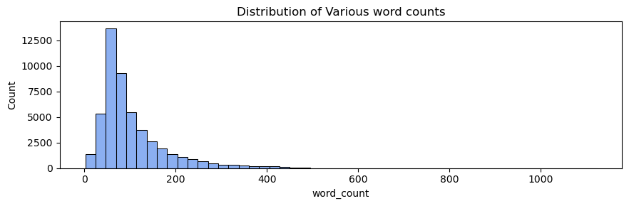

```python
# Plots a histogram of the number of words across the reviews.
# Note that the data appears "right-skewed".
numerical_feature_cols = ["word_count"]
plt.figure(figsize=[25, 3])
for i, col in enumerate(numerical_feature_cols):
    plt.subplot(1, 3, i + 1)
    sns.histplot(data=df, x=col, bins=50, color="#6495ED")
    plt.title(f"Distribution of Various word counts")
plt.tight_layout()
plt.show()
```

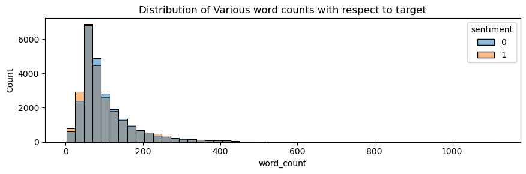

```python
plt.figure(figsize=[25, 3])
for i, col in enumerate(numerical_feature_cols):
    plt.subplot(1, 3, i + 1)
    sns.histplot(data=df, x=col, hue="sentiment", bins=50)
    plt.title(f"Distribution of Various word counts with respect to target")
plt.tight_layout()
plt.show()
```

```python
# Removes the column "word_count" from the DataFrame.
df.drop("word_count", axis=1, inplace=True)
```

```python
# Prints the distribution of sentiment (e.g., Positive or Negative).
df["sentiment"].value_counts()
```

```
sentiment
1    24884
0    24698
Name: count, dtype: int64
```

This code creates a pie chart to visualize the distribution of the sentiment variable in the DataFrame. The pie chart is created using the matplotlib.pyplot library. The code sets the figure size to 10x6 and assigns two colors, one for each sentiment label. The plt.pie function creates the actual pie chart using the counts of each sentiment label from the DataFrame. The autopct parameter sets the format for the percentages displayed on each wedge of the pie. The explode parameter creates a small gap between the two wedges to make them stand out. Finally, the title and y-label of the chart are set. The output shows that the distribution of sentiment in the dataset is almost evenly split between positive and negative, with positive being slightly more frequent at 50.19% when compared to the negative distribution of 49.81%.

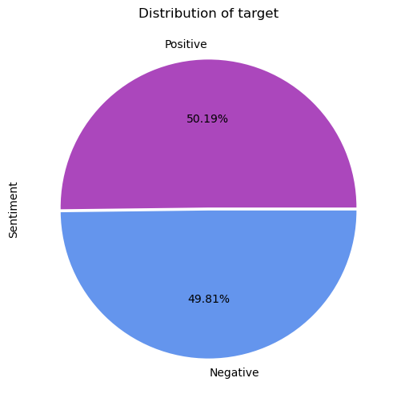

```python
plt.figure(figsize=(10, 6))
colors = ["#AB47BC", "#6495ED"]
plt.pie(
    df["sentiment"].value_counts(),
    labels=["Positive", "Negative"],
    autopct="%.2f%%",
    explode=[0.01, 0.01],
    colors=colors,
)
plt.title("Distribution of target")
plt.ylabel("Sentiment")
```

The code below selects three random reviews from the DataFrame and displays them with their corresponding sentiment label (positive or negative). With these text snippets being de-noised and with stop words removed - we can also get a general picture of the words that the models will be using to associate with negative and positive sentiments.

```python
# Prints the 3 random reviews.
random_index = random.randint(0, df.shape[0] - 3)
for row in df[["review", "sentiment"]][random_index : random_index + 3].itertuples():
    _, text, label = row
    class_name = "Positive"
    if label == 0:
        class_name = "Negative"
    display(HTML(f"<h5><b style='color:red'>Text: </b>{text}</h5>"))
    display(
        HTML(f"<h5><b style='color:red'>Target: </b>{class_name}<br><hr></h5>")
    )
```

**Text:** this basically run mill violent flick complete nifty music ok its slight notch much fare featured still equivalent driving nail kneecap slow painful to give away plot would exhaust energy ill say better skipping one

**Target:** Negative

**Text:** i sat last night see film greek television upcoming olympic city knowing american film already focus american story and really ready but saw mean movie title first athens even american origin would expect time ignorant towards the american seem nature strength smartness generosity kindness politeness contrast seem unable even speak express the number times american anthem film must time record megalomania even greek nation greek serving foreign marathon wine order help domestic win race so much olympic spirit think being greek bad mark movie whose title also greek something doesnt make happy but according seen cannot give pretty generous actually

**Target:** Negative

**Text:** what i say film narrative one exciting film history based true story being old enough remember berlin wall still used contain country film dark insight grim incarceration east desperate escape matter cost the film two decide escape balloon forever arrest scrutiny calculate plan reach side wall a tense thrilling story courage determination truly homage treacherous journey west berlin freedom

**Target:** Positive

### Length of sequence

We decided to set a maximum of 1000 words per review in order to work within our hardware and time constraints. Given that running our RNN models take a considerable amount of time to run, we decided that 1000 words would be a good balance between running our models at a reasonable time and our models training efficiently with enough words per review.

### Size and Nature of Vocabulary

We use a vocabulary text file that contains around 235,000 words. Given that a movie review could be written by anyone, we must consider different writing and word use styles. Therefore, we believe that using the entire vocabulary file for our tokenizer makes it less likely for our model to come across a English word it will not recognize and easier for our models to recognize the sentiment behind a combination of words, therefore preventing our models from becoming hindered in this aspect.

### Dataset Source

This dataset was created as part of a research experiment and publication. The authors of the research paper and dataset only included highly polarizing movie reviews, meaning that all positive reviews were a 7 or more out of 10, and negative reviews were a 4 or lower out of 10. Additionally, each unique movie mentioned in the reviews of the dataset has at most 30 reviews each.

Additonal information on the dataset can be found [here](http://ai.stanford.edu/~amaas/data/sentiment/) and more information on the research itself as well as the [research paper](http://ai.stanford.edu/~amaas/papers/wvSent_acl2011.pdf) published.

### Tokenizer

We use the tokenizer from Keras to tokenize the individual words as part of preparing the data for the natural language processing (NLP) tasks. The Tokenizer class from Keras is used to tokenize the text by replacing words with numbers. The resulting sequences are saved as a list containing lists of integers. The word_index dictionary is created from the tokenizer object, where the keys are words and the values are their corresponding integers. Finally, the code prints the first 10 sequences and the word index dictionary up to the 10th key-value pair.

```python
NUM_TOP_WORDS = None  # use entire vocabulary!
MAX_ART_LEN = 1000  # maximum and minimum number of words
```

```python
# Tokenize the text
tokenizer = Tokenizer(num_words=NUM_TOP_WORDS)
tokenizer.fit_on_texts(df["review"])
```

```python
# Save the sequences with integers (e.g., replaces words with numbers).
sequences = tokenizer.texts_to_sequences(df["review"])

# Prints the first 10 sequences.
sequences[0][:10]
```

```
[5, 63, 281, 2473, 121, 105, 464, 2, 23, 64]
```

```python
# Assigns the index to value
word_index = tokenizer.word_index

# Prints the word index dictionary
for i, (k, v) in enumerate(tokenizer.word_index.items(), start=1):
    print(k, v)
    if i == 10:
        break
```

```
i 1
the 2
movie 3
film 4
one 5
like 6
this 7
good 8
even 9
it 10
```

```python
# Assigns variable NUM_TOP_WORDS
NUM_TOP_WORDS = len(word_index) if NUM_TOP_WORDS == None else NUM_TOP_WORDS

# Prints the number of Top Words.
NUM_TOP_WORDS
```

```
34104
```

```python
# Assigns top_words variable
top_words = min((len(word_index), NUM_TOP_WORDS))
```

```python
print(
    f"Found {len(word_index)} unique tokens. Distilled to {top_words} top words."
)
```

```
Found 34104 unique tokens. Distilled to 34104 top words.
```

```python
# Defines x values to array of padded sequences
X = pad_sequences(sequences, maxlen=MAX_ART_LEN)

print("Shape of data tensor:", X.shape, "\nMax X:", np.max(X))
```

```
Shape of data tensor: (49582, 1000)
Max X: 34104
```

```python
# One-hot encodes the column sentiment and set to y.
y_ohe = keras.utils.to_categorical(df["sentiment"])

print("Shape of label tensor:", y_ohe.shape)
```

```
Shape of label tensor: (49582, 2)
```

### Evalutation Methods

✅ Choose and explain what metric(s) you will use to evaluate your algorithm’s performance. You should give a detailed argument for why this (these) metric(s) are appropriate on your data.  
That is, why is the metric appropriate for the task (e.g., in terms of the business case for the task). Please note: rarely is accuracy the best evaluation metric to use. Think deeply about an appropriate measure of performance.

We will evaluate our models using different evaluation methods:

Accuracy is a measure of the overall correctness of a model's predictions, calculated as the ratio of the number of correct predictions to the total number of predictions. Accuracy provides us with a basic understanding of how our models are performing. It will not be our only evaluation method since accuracy only provides surface-level information and does not consider the full impact of false positives and negatives.

Misclass, or misclassification, refers to the instances where a model's prediction does not match the actual class label of a data point.

Precision is a measure of how well a model correctly identifies positive instances among the predicted positive instances. Given the nature of our dataset, we want to account for whether our model predicted a review to be negative when it was acutally positive (false positive) as movie reviews can influence the reputation of the movie.

Recall, also known as sensitivity or the true positive rate, is a measure of how well a model identifies all the positive instances among the actual positive instances. Given the nature of our dataset, we want to account for whether our model predicted a review to be positive when it was acutally negative (false negative) as movie reviews can influence the reputation of the movie.

F1-score is the "harmonic mean" of precision and recall, providing a single value that balances the trade-off between precision and recall.

Additionally, we graph the values of Loss and AUC (Area Under Curve) for comparisons.

We want to consider all of these metrics since not only do we want our models to perform well, but we want to achieve the highest true positive rate for both classes as possible. Given the importance of recognizing false positive and negatives, especially false negative reviews can have a greater impact on a movie's reputation than false positives, we need to measure and quantify the performance of our models by these evaluation methods.

### Data Splitting Method

✅ Choose the method you will use for dividing your data into training and testing (i.e., are you using Stratified 10-fold cross validation? Shuffle splits? Why?).  
Explain why your chosen method is appropriate or use more than one method as appropriate. Convince me that your train/test splitting method is a realistic mirroring of how an algorithm would be used in practice.

We chose to split our dataset using the train_test_split() function from the the sklearn.model_selection library. Our training and testing dataset contains around 2,000 observations each in order to run our models in a reasonable amount of time. Assuming that our dataset was only composed on 4,000 observations, the split would be 50/50 for training and testing. Since we used the stratify parameter in the train_test_split() function and passed in our target value, we ensure that the class distribution of this sub-dataset will be balanced like the overall dataset.

Our main motivation to shorten our dataset is due to resource usage and hardware constraints. Training an RNN on a large dataset can be computationally expensive and can take a significant amount of time.  
Therefore, by decreasing the number of observations, it is possible to run the models within a reasonable timeframe.

While reducing the number of observations may impact the accuracy and convergence of the model, the goal of the project is to demonstrate the implementation of RNNs, and 4,000 observations total is still sufficient to showcase the architecture and functionality.

```python
# Defines the number of classes in the dataset
NUM_CLASSES = 2
```

The code below splits the data into training and testing sets using the train_test_split() function from the scikit-learn library. The X and y_ohe variables contain the independent and dependent variables, respectively. The train_size and test_size parameters specify the number of observations in the training and testing sets, respectively. The stratify parameter is used to ensure that the distribution of the target variable (sentiment) is roughly equal in the training and testing sets.

This is important to ensure that the models trained on the data generalize well to new, unseen data to prevent the models from overfitting. The random_state parameter is used to ensure that the data is split in a consistent manner across different runs of the code. Finally, the code prints the shape of the training and testing sets to confirm that the split was successful and that the sizes of the two sets match the specified values.

```python
# Splits data into training and testing.
X_train, X_test, y_train_ohe, y_test_ohe = train_test_split(
    X, y_ohe, train_size=2000, test_size=2000, stratify=df["sentiment"], random_state=123
)

# Prints the value counts (e.g., shape) for the training and testing data.
print(f"""\
Training and Testing Data Split
===============================
X-Train: {X_train.shape}
X-Test: {X_test.shape}
Y-Train: {y_train_ohe.shape}
Y-Test: {y_train_ohe.shape}
""")
```

```
Training and Testing Data Split
===============================
X-Train: (2000, 1000)
X-Test: (2000, 1000)
Y-Train: (2000, 2)
Y-Test: (2000, 2)
```

The code below calculates the number of observations for each unique class in the target variable and plots the distribution of the class count. The output is a bar plot that shows the count of each unique class in the target variable. The x-axis represents the classes ("Negative" and "Positive") and the y-axis represents the count of each class. The plot shows that the dataset is well balanced, and the distribution of positive to negative sentiment reviews is (or is at least very near) 1:1.

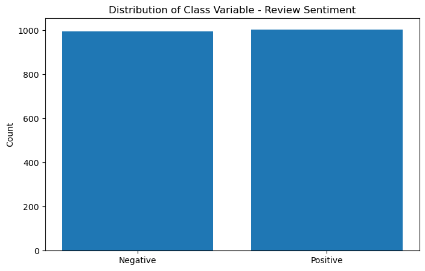

```python
# Determines the count of unique classes.
uniq_classes = np.sum(y_train_ohe, axis=0)

# Plots the class count distribution.
fig = plt.figure(figsize=[8, 5])
plt.bar([0, 1], uniq_classes)
plt.xticks([0, 1], labels=["Negative", "Positive"], rotation="horizontal", )
plt.ylabel("Count")
plt.title("Distribution of Class Variable - Review Sentiment")
plt.show()
```

## Modeling

✅ Investigate at least two different recurrent network architectures Be sure to use an embedding layer . Adjust hyper-parameters of the networks as needed to improve generalization performance (train a total of at least four models).  
Discuss the performance of each network and compare them. Justify your choice of parameters for each.

We will create 5 RNN models in total for this section. RNN1 and RNN3 will be implemented with the the Long-Short-Term Memory (LSTM) architecture, while RNN2 and RNN4 will be implemented with the Gated Recurrent Unit (GRU) architecture. The architecture of RNN5 will depend on which of our first four models performs the best. RNN5 will be a copy of our best performance model, which then we will add a second recurrent chain and compare its performance to the performance of our first four models.

### GloVe Embedding

✅ Use the Glove pre-trained embedding. Provide justification of the embedding size.

We feel that 50 is a reasonable size for EMBED_SIZE. The size of the word embedding depends on the size of the corpus, the number of unique words, and the context window used to generate the embeddings.  
In general, a larger embedding size tends to capture more complex semantic relationships between words, but this also requires more memory and computational resources.  
Whereas smaller sizes may be suitable for smaller datasets or limited computing resources.  
We observed that an embedding size of 50 strikes a balance in capturing relationships between words while also not draining our limited resources and taking an excess amount of time.

```python
# Defines the embedding size
EMBED_SIZE = 50
```

```python
# Defines name of glove text file.
glove_file = "glove.6B.50d.txt"

# Reads the glove file into memory.
with open(glove_file, "r", encoding="utf-8") as file:
    glove_data = file.readlines()
```

The code below loads pre-trained GloVe embeddings to use as initial weights for the model. The GloVe embeddings are stored in a text file, and the code reads the file into memory and parses the contents to obtain the embeddings for individual words. The embeddings are then stored in a dictionary, where each word is associated with a corresponding embedding vector. The size of each embedding vector is defined by the EMBED_SIZE constant.

Next, the code initializes an empty embedding matrix, which will be used to store the embeddings for the words in the training set. The matrix has dimensions (num_words, EMBED_SIZE), where num_words is the total number of unique words in the training set.

For each word in the word_index dictionary (which maps words to integer indices), the code checks if an embedding vector exists in the embeddings_index dictionary for that word. If an embedding vector exists, it is added to the embedding matrix at the corresponding index. If an embedding vector does not exist (i.e., the word is not in the pre-trained GloVe embeddings), the corresponding row in the embedding matrix remains all zeros.

Finally, the code prints the total number of word vectors found in the GloVe embeddings, as well as the number of words in the training set for which embeddings were found.

```python
# Assigning embedding index
embeddings_index = {}

# Assigns glove data to embeddings dictionary.
for i, line in enumerate(glove_data):
    values = line.split()
    if values:
        word = values[0]
        coefs = np.asarray(values[1:], dtype="float32")
        embeddings_index[word] = coefs

# Prints the number of word vectors.
print("Found %s word vectors." % len(embeddings_index))
```

```
Found 400000 word vectors.
```

```python
# Fills in the matrix using the ordering from the keras
# word tokenizer that was implemented previously.
found_words = 0
embedding_matrix = np.zeros((len(word_index) + 1, EMBED_SIZE))
for word, i in word_index.items():
    embedding_vector = embeddings_index.get(word)
    if embedding_vector is not None:
        # words not found in embedding index will be ALL-ZEROS
        embedding_matrix[i] = embedding_vector
        found_words = found_words + 1
```

```python
# Prints the data for the found words and embedding matrix.
print(f"""\
Embedding Shape: {embedding_matrix.shape}
Total Words Found: {found_words}
Percentage: {found_words / embedding_matrix.shape[0] * 100:.3f}
""")
```

```
Embedding Shape: (34105, 50)
Total Words Found: 31805
Percentage: 93.256
```

This code defines an embedding layer using Keras' Embedding() function. The layer is initialized with the embedding matrix embedding_matrix, which contains pre-trained word embeddings loaded from the GloVe file. The weights parameter of the Embedding() function is used to load these pre-trained embeddings. The trainable parameter is set to False to keep the pre-trained embeddings fixed during training. The other parameters specify the size of the input layer and the maximum length of input sequences.

```python
# Saves the embedding layer
embedding_layer = Embedding(
    len(word_index) + 1,
    EMBED_SIZE,
    weights=[embedding_matrix],  # here is the embedding getting saved
    input_length=MAX_ART_LEN,
    trainable=False,
)
```

The review_test() helper function defined below tests a single review on a trained model to get the prediction. The function takes the trained model, the index of the review to be tested, and the test dataframe as arguments. The function then extracts the text and true label from the test dataframe using the provided index, displays the text and true label, and vectorizes the text using a pre-fitted tokenizer instance. The function then pads the text to have the same shape as the input to the embedding layer, feeds it to the model, and gets the predicted sentiment by performing an argmax operation on the model's output. Finally, the function displays the predicted sentiment.

```python
def review_test(model, index, test_df):
    """
    Tests a body of text on the trained model to get the prediction.
    """
    text = test_df["review"][index]
    display(HTML(f"<h5><b style='color:red'>Text: </b>{text}</h5>"))

    true_label = test_df["sentiment"][index]
    true_val = "negative" if true_label == 0 else "positive"
    display(HTML(f"<h5><b style='color:red'>Actual: </b>{true_val}</h5>"))

    # vectorizing the text by the pre-fitted tokenizer instance
    text = tokenizer.texts_to_sequences(text)

    # padding the text to have exactly the same shape as `embedding` input
    text = pad_sequences(text, maxlen=MAX_ART_LEN, dtype="int32", value=0)

    sentiment = np.argmax(
        model.predict(text, batch_size=512, verbose=2)[0], axis=0
    )
    pred_val = "negative" if sentiment == 0 else "positive"
    display(HTML(f"<h5><b style='color:red'>Predicted: </b>{pred_val}</h5>"))
```

The helper function below creates a confusion matrix plot for a given sklearn confusion matrix, with several optional parameters. The function takes in a confusion matrix, the names of the classification classes, a title, a colormap, and a boolean to specify whether to plot the raw numbers or proportions. If normalize is True, the proportions are shown. The plot includes a color bar and the true and predicted labels as x and y-axis labels. The accuracy and misclassification rates are also displayed in the plot. The function also allows an optional argument class_results, which is a dictionary containing class-specific metrics to display.

```python
def plot_confusion_matrix(
    cm,
    target_names,
    title="Confusion matrix",
    cmap=None,
    normalize=True,
    class_results: dict = {},
):
    """
    Given a sklearn confusion matrix (cm), make a nice plot

    Arguments
    ---------
    cm:           confusion matrix from sklearn.metrics.confusion_matrix

    target_names: given classification classes such as [0, 1, 2]
                  the class names, for example: ['high', 'medium', 'low']

    title:        the text to display at the top of the matrix

    cmap:         the gradient of the values displayed from matplotlib.pyplot.cm
                  see http://matplotlib.org/examples/color/colormaps_reference.html
                  plt.get_cmap('jet') or plt.cm.Blues

    normalize:    If False, plot the raw numbers
                  If True, plot the proportions

    Usage
    -----
    plot_confusion_matrix(cm           = cm,                  # confusion matrix created by
                                                              # sklearn.metrics.confusion_matrix
                          normalize    = True,                # show proportions
                          target_names = y_labels_vals,       # list of names of the classes
                          title        = best_estimator_name) # title of graph

    Citiation
    ---------
    http://scikit-learn.org/stable/auto_examples/model_selection/plot_confusion_matrix.html

    """
    accuracy = np.trace(cm) / float(np.sum(cm))
    misclass = 1 - accuracy

    if cmap is None:
        cmap = plt.get_cmap("Blues")

    plt.figure(figsize=(8, 6))
    plt.imshow(cm, interpolation="nearest", cmap=cmap)
    plt.title(title)
    plt.colorbar()

    if target_names is not None:
        tick_marks = np.arange(len(target_names))
        plt.xticks(tick_marks, target_names, rotation=45)
        plt.yticks(tick_marks, target_names)

    if normalize:
        cm = cm.astype("float") / cm.sum(axis=1)[:, np.newaxis]

    thresh = cm.max() / 1.5 if normalize else cm.max() / 2
    for i, j in itertools.product(range(cm.shape[0]), range(cm.shape[1])):
        if normalize:
            plt.text(
                j,
                i,
                "{:0.4f}".format(cm[i, j]),
                horizontalalignment="center",
                color="white" if cm[i, j] > thresh else "black",
            )
        else:
            plt.text(
                j,
                i,
                "{:,}".format(cm[i, j]),
                horizontalalignment="center",
                color="white" if cm[i, j] > thresh else "black",
            )

    plt.tight_layout()
    plt.ylabel("True label")
    if class_results:
        x_lab = "Predicted label\n\n"
        x_lab += f"accuracy={accuracy:0.4f}\nmisclass={misclass:0.4f}\n"
        for key, value in class_results.items():
            x_lab += f"{key}={value:0.4f}\n"
    else:
        x_lab = "Predicted label\n\n"
        x_lab += f"accuracy={accuracy:0.4f}\nmisclass={misclass:0.4f}\n"

    plt.xlabel(x_lab)
    plt.show()
```

### RNN1

The given code is a Keras model for a Recurrent Neural Network (RNN) with an Embedding layer, a Long Short-Term Memory (LSTM) layer, and a Dense layer. The model is compiled with the Adamax optimizer, mean squared error (MSE) loss, and uses two metrics: Recall and AUC. The model is then trained on training data X_train and y_train_ohe for 15 epochs and a batch size of 512, and validated using the testing data X_test and y_test_ohe. The summary of the model is displayed using the summary() function of the model.

The output shows a summary of the RNN model with its layers and the number of parameters in each layer. The model has a total of 1,765,852 parameters, out of which 60,602 are trainable, and the remaining 1,705,250 are non-trainable because they belong to the Embedding layer. The model has an Embedding layer that takes input of shape (None, 1000) and outputs a tensor of shape (None, 1000, 50), indicating that the input has 1000 words, and each word is represented by a 50-dimensional vector. The LSTM layer takes the output of the Embedding layer as input and produces a tensor of shape (None, 100) as output. Finally, the Dense layer produces a tensor of shape (None, 2) as output, representing the probabilities of the two classes in the binary classification problem.

```python
rnn = Sequential()
rnn.add(embedding_layer)
rnn.add(LSTM(100, dropout=0.3, recurrent_dropout=0.3))
rnn.add(Dense(NUM_CLASSES, activation="softmax"))
rnn.compile(
    optimizer="Adamax",
    loss="mse",
    metrics=[keras.metrics.Recall(), keras.metrics.AUC()],
)

rnn_history = rnn.fit(
    X_train,
    y_train_ohe,
    validation_data=(X_test, y_test_ohe),
    epochs=EPOCHS,
    batch_size=512,
)
clear_screen()

rnn.summary()
```

```
Model: "sequential_2"
_________________________________________________________________
 Layer (type)                Output Shape              Param #
=================================================================
 embedding_3 (Embedding)     (None, 1000, 50)          1705250

 lstm_2 (LSTM)               (None, 100)               60400

 dense_2 (Dense)             (None, 2)                 202

=================================================================
Total params: 1,765,852
Trainable params: 60,602
Non-trainable params: 1,705,250
_________________________________________________________________
```

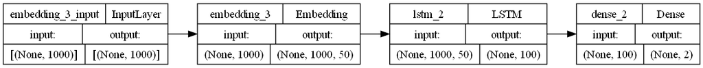

```python
# Plots the graph
utils.plot_model(
    rnn,
    to_file="model.png",
    show_shapes=True,
    show_layer_names=True,
    rankdir="LR",
    expand_nested=False,
    dpi=96,
)
```

Below, we generate predictions using RNN1 and print the classification report based on the actual test data and predicted data. The y_predict_proba array contains the predicted probabilities for each class, while the y_predict array is the binary predicted output by rounding off these probabilities.

The classification_report() function from scikit-learn is then used to print the precision, recall, and F1-score for both classes (0 and 1), as well as micro, macro, weighted, and samples average scores for the model's overall performance.

In this case, the model achieves an average F1-score and precision score of 0.76 for both classes, and average recall score of 0.75 for class 0 and 0.77 for class 1.

```python
# Defines the y-prediction probability and y-prediction arrays
y_predict_proba = rnn.predict(X_test)
y_predict = np.round(y_predict_proba)

clear_screen()

# Prints classification report
print(classification_report(y_test_ohe, y_predict, zero_division=0))
```

```
              precision    recall  f1-score   support

           0       0.76      0.75      0.76       996
           1       0.76      0.77      0.76      1004

   micro avg       0.76      0.76      0.76      2000
   macro avg       0.76      0.76      0.76      2000
weighted avg       0.76      0.76      0.76      2000
 samples avg       0.76      0.76      0.76      2000
```

Below we compute the accuracy of the model's predictions on the test dataset using the accuracy_score() function from the scikit-learn library and then print the result as a percentage with 2 decimal places.

The accuracy is 76%, which means that 76% of the test data instances were classified correctly by the model. While this result is certainly better than a 50% coin toss prediction - there is room for improvement.

```python
acc_1 = mt.accuracy_score(y_test_ohe, y_predict)
print(f"Accuracy: {acc_1 * 100:.2f}%")
```

```
Accuracy: 76.00%
```

Below we generate a loss graph of the training process for RNN1. The loss values are collected from the rnn_history object, which stores the loss values for each epoch during the training process. The code then plots the loss values against the number of epochs using Matplotlib.

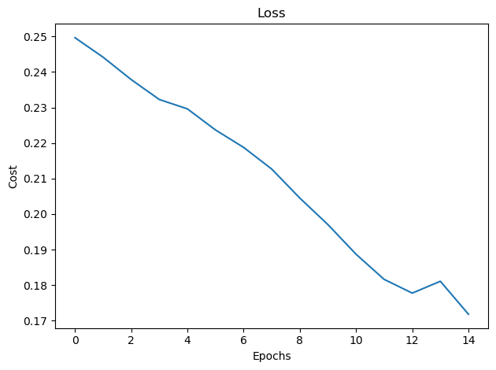

```python
# Variables for determining the loss over epochs
epochs = rnn_history.epoch
loss = rnn_history.history["loss"]

# Plots the loss graph
plt.plot(epochs, loss)
plt.ylabel("Cost")
plt.xlabel("Epochs")
plt.title("Loss")

plt.tight_layout()

plt.show()
```

The code below evaluates and visualizes the Receiver Operating Characteristic (ROC) curve and Area Under the Curve (AUC) for RNN1. The ROC curve is a graphical representation of the performance of a binary classification system, showing the trade-off between the true positive rate (TPR) and the false positive rate (FPR) as the decision threshold for classification is varied. The AUC is a metric that summarizes the overall performance of the model, with a higher AUC indicating better performance.

Our AUC for this run is 0.76 indicating that the model has a decent ability to distinguish between positive and negative cases. The ROC curve visualizes this by showing a rise in the curve until reaching a point where the TPR is 0.8 and the FPR is 0.2. From there, it gradually increases until reaching the end of the graph indicating that the model is able to identify some positive cases while making errors with some false positive predictions. Overall, this suggests that the RNN model is able to make correct predictions without guessing or randomly choosing a class label, but there is still room for improvement.

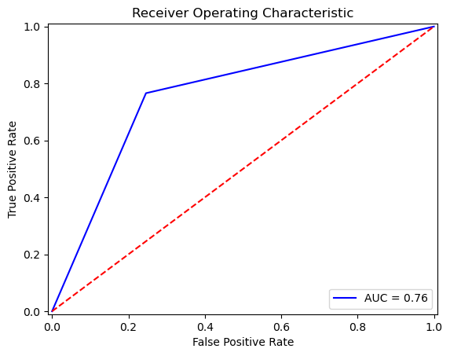

```python
# Variables for determining the ROC/AUC
fpr, tpr, threshold = roc_curve(
    np.argmax(y_test_ohe, axis=1), np.argmax(y_predict_proba, axis=1)
)
roc_auc = auc(fpr, tpr)

# Plots the ROC and AUC graph
plt.title("Receiver Operating Characteristic")
plt.plot(fpr, tpr, "b", label="AUC = %0.2f" % roc_auc)
plt.legend(loc="lower right")
plt.plot([0, 1], [0, 1], "r--")
plt.xlim([-0.01, 1.01])
plt.ylim([-0.01, 1.01])
plt.ylabel("True Positive Rate")
plt.xlabel("False Positive Rate")
plt.show()
```

The code below plots the training versus testing graph for RNN1. The graph has three subplots: the first subplot shows the training and validation loss versus epochs, the second subplot shows the training and validation recall versus epochs, and the third subplot shows the training and validation AUC versus epochs.

The training versus testing graph is used to visualize the performance of the model during training. We can see that the training loss and validation loss decrease at a stable rate as the number of epochs increases, and since the training curve has higher loss values than the validation curve, the graph indicates that the model is learning and improving.

The training recall and validation recall also increase as the number of epochs increases, and with the validation curve having higher values than the training curve, the graph indicatees that the model is becoming better at identifying the sentiment of reviews.

Finally, the training AUC and validation AUC increase as the number of epochs increases, and with the validation curve having higher values than the training curve, the graph indicates that the model is becoming better at distinguishing between positive and negative sentiment in reviews.

Overall, the graph shows that the RNN model is improving over time, and that it is performing well on both the training and validation sets.

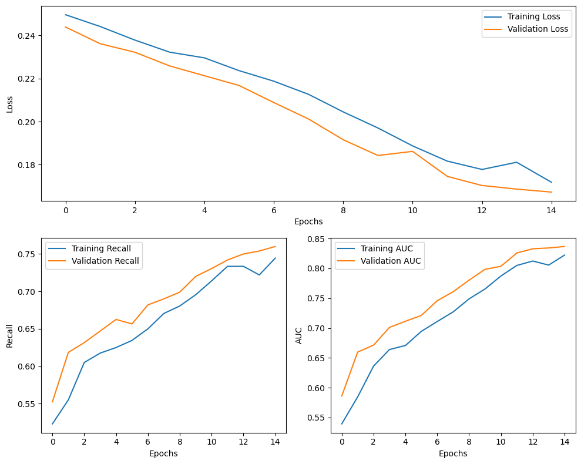

```python
# Model history values
hist_values = list(rnn_history.history.values())

# Variables for plotting the training versus testing
train_loss   = hist_values[0]
train_recall = hist_values[1]
train_auc    = hist_values[2]
val_loss     = hist_values[3]
val_recall   = hist_values[4]
val_auc      = hist_values[5]

# Plots the training versus testing graph
plt.figure(figsize=(10, 8))
plt.subplot(2, 2, (1, 2))
plt.plot(train_loss, label="Training Loss")
plt.plot(val_loss, label="Validation Loss")
plt.xlabel("Epochs")
plt.ylabel("Loss")
plt.legend()

plt.subplot(2, 2, 3)
plt.plot(train_recall, label="Training Recall")
plt.plot(val_recall, label="Validation Recall")
plt.xlabel("Epochs")
plt.ylabel("Recall")
plt.legend()

plt.subplot(2, 2, 4)
plt.plot(train_auc, label="Training AUC")
plt.plot(val_auc, label="Validation AUC")
plt.xlabel("Epochs")
plt.ylabel("AUC")
plt.legend()

plt.tight_layout()

plt.show()
```

In this run, RNN1 predicted 751 Negative sentiments and 769 Positive sentiments correctly, while mispredicting 245 and 235 Negative and Positive sentiments respectively. The model does not show any bias towards any class in the images that it misclassified since the distribution of false positives and false negatives is balanced.

Accuracy is a measure of the overall correctness of a model's predictions, calculated as the ratio of the number of correct predictions to the total number of predictions. For this run, our initial accuracy score is 0.76 or roughly 76%.

Misclass, or misclassification, refers to the instances where a model's prediction does not match the actual class label of a data point. Misclassification can be measured using various metrics such as accuracy, precision, recall, and F1-score - but in this case we can easily determine misclass by calculating 1.0 minus the accuracy score. In our case, we observe the misclass as 0.24 or 24%.

Precision is a measure of how well a model correctly identifies positive instances among the predicted positive instances. Precision is calculated as the ratio of the number of true positive predictions to the total number of positive predictions (which would be the true positive predictions plus the false positive predictions). In our case, the precision score is 0.76 or 76%. It is the same as our accuracy value which we feel is ideal for finding a viable solution for field-use as it is important to minimize false positives and maximize true positives.

Recall, also known as sensitivity or the true positive rate, is a measure of how well a model identifies all the positive instances among the actual positive instances. Recall is calculated as the ratio of the number of true positive predictions to the total number of actual positive instances (i.e., sum of true positive and false negative predictions). Our recall score for this run was 0.76 or 76% - exactly the same as our accuracy.

F1-score is the "harmonic mean" of precision and recall, providing a single value that balances the trade-off between precision and recall. It is calculated as 2 *(precision* recall) / (precision + recall). Our F1-score for this run was 0.76 or roughly 76%.

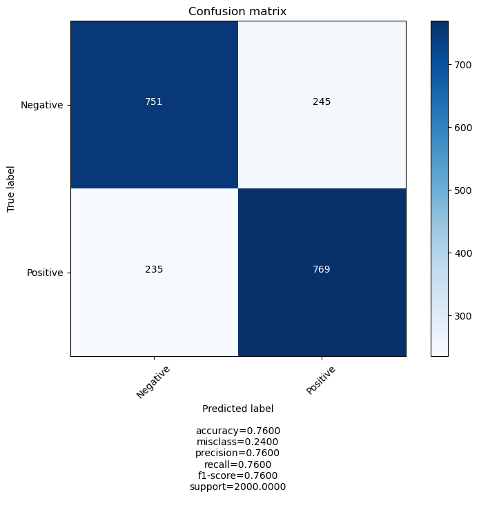

```python
class_report = classification_report(
    y_test_ohe, y_predict, output_dict=True
)

plot_confusion_matrix(
    confusion_matrix(
        np.argmax(y_test_ohe, axis=1), np.argmax(y_predict, axis=1)
    ),
    [classes[0], classes[1]],
    normalize=False,
    class_results=class_report["weighted avg"],
)
```

Below, we make a prediction using RNN1 on a randomly selected review from the dataset df. The review text and the actual label are displayed, followed by the predicted label.

In this case, both the actual and predicted label are negative - meaning that the model correctly predicted the sentiment for this sample review.

```python
# Observe how the model predicts a review
review_test(rnn, random.randint(1, 10000), df)
```

**Text:** although unusually second string vivid clothes lead bring life flatly directed screenplay the plot around newly parole go straight vengeful man scenery fred clark determined involve bank robbery whether want as cole younger wayne morris big hunky enough cool wooden acting undermine the standard action frankly better gene roy episode colt never need uncanny shooting allow horse rider shoot hip wound man least oh dear

**Actual:** negative

```
1/1 - 1s - 981ms/epoch - 981ms/step
```

**Predicted:** negative

### RNN 2

The given code is a Keras model for a Recurrent Neural Network (RNN) with an Embedding layer, a Gated Recurrent Unit (GRU) layer, and a Dense layer. The model is compiled with the Adamax optimizer, mean squared error (MSE) loss, and uses two metrics: Recall and AUC. The model is then trained on training data X_train and y_train_ohe for 15 epochs and a batch size of 512, and validated using the testing data X_test and y_test_ohe. The summary of the model is displayed using the summary() function of the model.

The output shows a summary of the RNN model with its layers and the number of parameters in each layer. The model has a total of 1,751,052 parameters, out of which 45,802 are trainable, and the remaining 1,705,250 are non-trainable because they belong to the Embedding layer. The model has an Embedding layer that takes input of shape (None, 1000) and outputs a tensor of shape (None, 1000, 50), indicating that the input has 1000 words, and each word is represented by a 50-dimensional vector. The GRU layer takes the output of the Embedding layer as input and produces a tensor of shape (None, 100) as output. Finally, the Dense layer produces a tensor of shape (None, 2) as output, representing the probabilities of the two classes in the binary classification problem.

GRU Statesize = 100

dropout = 0.2

recurrent dropout = 0.2

```python
# create GRU
gru = Sequential()
gru.add(embedding_layer)
gru.add(GRU(100, dropout=0.2, recurrent_dropout=0.2))
gru.add(Dense(NUM_CLASSES, activation="sigmoid"))
gru.compile(
    optimizer="Adamax",
    loss="mse",
    metrics=[keras.metrics.Recall(), keras.metrics.AUC()],
)

gru_history = gru.fit(
    X_train,
    y_train_ohe,
    validation_data=(X_test, y_test_ohe),
    epochs=EPOCHS,
    batch_size=512,
)

clear_screen()

gru.summary()
```

```
Model: "sequential_3"
_________________________________________________________________
 Layer (type)                Output Shape              Param #
=================================================================
 embedding_3 (Embedding)     (None, 1000, 50)          1705250

 gru (GRU)                   (None, 100)               45600

 dense_3 (Dense)             (None, 2)                 202

=================================================================
Total params: 1,751,052
Trainable params: 45,802
Non-trainable params: 1,705,250
_________________________________________________________________
```

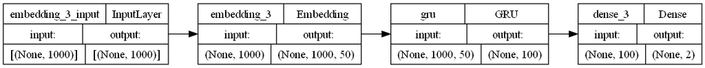

```python
# Plots the graph
utils.plot_model(
    gru,
    to_file="model.png",
    show_shapes=True,
    show_layer_names=True,
    rankdir="LR",
    expand_nested=False,
    dpi=96,
)
```

Below, we generate predictions using RNN2 and print the classification report based on the actual test data and predicted data. The y_predict_proba array contains the predicted probabilities for each class, while the y_predict array is the binary predicted output by rounding off these probabilities.

The classification_report() function from scikit-learn is then used to print the precision, recall, and F1-score for both classes (0 and 1), as well as micro, macro, weighted, and samples average scores for the model's overall performance.

```python
# Defines the y-prediction probability and y-prediction arrays
y_predict_proba = gru.predict(X_test)
y_predict = np.round(y_predict_proba)

clear_screen()

# Prints classification report
print(classification_report(y_test_ohe, y_predict, zero_division=0))
```

```
              precision    recall  f1-score   support

           0       0.66      0.68      0.67       996
           1       0.67      0.64      0.66      1004

   micro avg       0.67      0.66      0.66      2000
   macro avg       0.67      0.66      0.66      2000
weighted avg       0.67      0.66      0.66      2000
 samples avg       0.64      0.66      0.65      2000
```

Below we compute the accuracy of the model's predictions on the test dataset using the accuracy_score() function from the scikit-learn library and then print the result as a percentage with 2 decimal places.

```python
acc_2 = mt.accuracy_score(y_test_ohe, y_predict)
print(f"Accuracy: {acc_2 * 100:.2f}%")
```

```
Accuracy: 62.00%
```

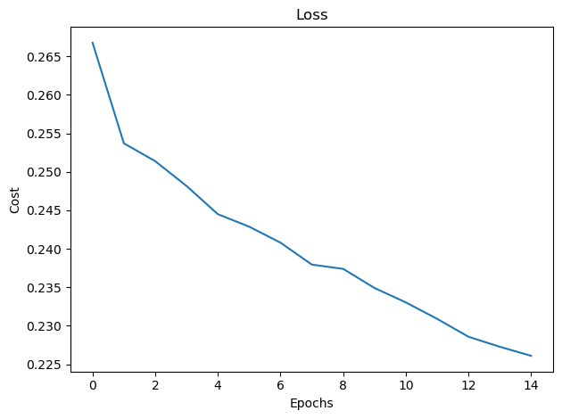

```python
# Variables for determining the loss over epochs
epochs = gru_history.epoch
loss = gru_history.history["loss"]

# Plots the loss graph
plt.plot(epochs, loss)
plt.ylabel("Cost")
plt.xlabel("Epochs")
plt.title("Loss")

plt.tight_layout()

plt.show()
```

The code below evaluates and visualizes the Receiver Operating Characteristic (ROC) curve and Area Under the Curve (AUC) for RNN2. The ROC curve is a graphical representation of the performance of a binary classification system, showing the trade-off between the true positive rate (TPR) and the false positive rate (FPR) as the decision threshold for classification is varied. The AUC is a metric that summarizes the overall performance of the model, with a higher AUC indicating better performance.

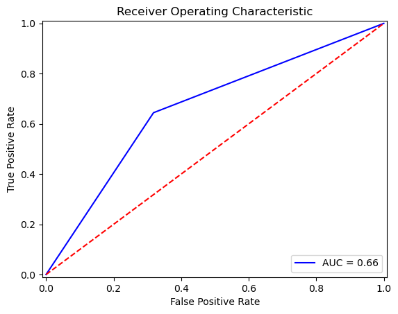

```python
# Variables for determining the ROC/AUC
fpr, tpr, threshold = roc_curve(
    np.argmax(y_test_ohe, axis=1), np.argmax(y_predict_proba, axis=1)
)
roc_auc = auc(fpr, tpr)

# Plots the ROC and AUC graph
plt.title("Receiver Operating Characteristic")
plt.plot(fpr, tpr, "b", label="AUC = %0.2f" % roc_auc)
plt.legend(loc="lower right")
plt.plot([0, 1], [0, 1], "r--")
plt.xlim([-0.01, 1.01])
plt.ylim([-0.01, 1.01])
plt.ylabel("True Positive Rate")
plt.xlabel("False Positive Rate")
plt.show()
```

The code below plots the training versus testing graph for RNN2. The graph has three subplots: the first subplot shows the training and validation loss versus epochs, the second subplot shows the training and validation recall versus epochs, and the third subplot shows the training and validation AUC versus epochs.

The training versus testing graph is used to visualize the performance of the model during training. We can see that the training loss and validation loss decrease at a stable rate as the number of epochs increases, and since the training curve has higher loss values than the validation curve, the graph indicates that the model is learning and improving.

Finally, the training AUC and validation AUC increase as the number of epochs increases, and with the validation curve having higher values than the training curve, the graph indicates that the model is becoming better at distinguishing between positive and negative sentiment in reviews.

Overall, the graph shows that the RNN model is improving over time, and that it is performing well on both the training and validation sets.

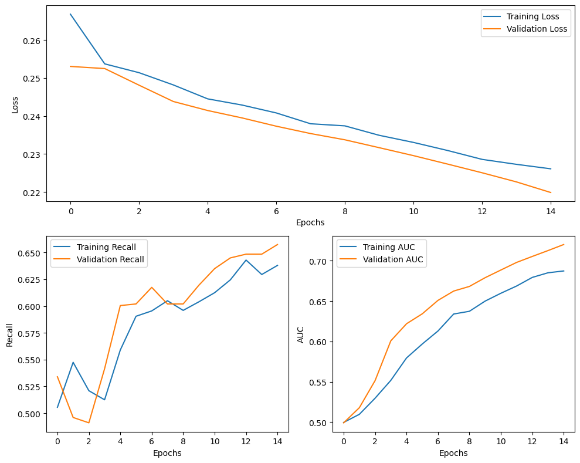

```python
# Model history values
hist_values = list(gru_history.history.values())

# Variables for plotting the training versus testing
train_loss   = hist_values[0]
train_recall = hist_values[1]
train_auc    = hist_values[2]
val_loss     = hist_values[3]
val_recall   = hist_values[4]
val_auc      = hist_values[5]

# Plots the training versus testing graph
plt.figure(figsize=(10, 8))
plt.subplot(2, 2, (1, 2))
plt.plot(train_loss, label="Training Loss")
plt.plot(val_loss, label="Validation Loss")
plt.xlabel("Epochs")
plt.ylabel("Loss")
plt.legend()

plt.subplot(2, 2, 3)
plt.plot(train_recall, label="Training Recall")
plt.plot(val_recall, label="Validation Recall")
plt.xlabel("Epochs")
plt.ylabel("Recall")
plt.legend()

plt.subplot(2, 2, 4)
plt.plot(train_auc, label="Training AUC")
plt.plot(val_auc, label="Validation AUC")
plt.xlabel("Epochs")
plt.ylabel("AUC")
plt.legend()

plt.tight_layout()

plt.show()
```

Accuracy is a measure of the overall correctness of a model's predictions, calculated as the ratio of the number of correct predictions to the total number of predictions. For this run, our initial accuracy score is 0.66 or roughly 66%.

Misclass, or misclassification, refers to the instances where a model's prediction does not match the actual class label of a data point. Misclassification can be measured using various metrics such as accuracy, precision, recall, and F1-score - but in this case we can easily determine misclass by calculating 1.0 minus the accuracy score. In our case, we observe the misclass as 0.33 or 33%.

Precision is a measure of how well a model correctly identifies positive instances among the predicted positive instances. Precision is calculated as the ratio of the number of true positive predictions to the total number of positive predictions (which would be the true positive predictions plus the false positive predictions). In our case, the precision score is 0.66 or 66%. It is the same as our accuracy value which we feel is ideal for finding a viable solution for field-use as it is important to minimize false positives and maximize true positives.

Recall, also known as sensitivity or the true positive rate, is a measure of how well a model identifies all the positive instances among the actual positive instances. Recall is calculated as the ratio of the number of true positive predictions to the total number of actual positive instances (i.e., sum of true positive and false negative predictions). Our recall score for this run was 0.65 or 65% - just below our accuracy score.

F1-score is the "harmonic mean" of precision and recall, providing a single value that balances the trade-off between precision and recall. It is calculated as 2 *(precision* recall) / (precision + recall). Our F1-score for this run was 0.66 or roughly 66%.

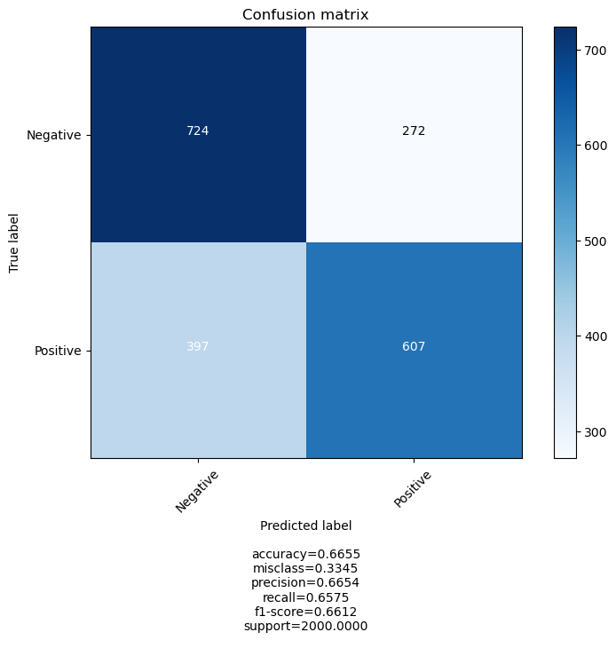

```python
class_report = classification_report(
    y_test_ohe, y_predict, zero_division=0, output_dict=True
)

plot_confusion_matrix(
    confusion_matrix(
        np.argmax(y_test_ohe, axis=1), np.argmax(y_predict, axis=1)
    ),
    [classes[0], classes[1]],
    normalize=False,
    class_results=class_report["weighted avg"],
)
```

Below, we make a prediction using RNN2 on a randomly selected review from the dataset df. The review text and the actual label are displayed, followed by the predicted label.

In this case, both the actual and predicted label are positive - meaning that the model correctly predicted the sentiment for this sample review.

```python
# Observe how the model predicts a review
review_test(gru, random.randint(1, 10000), df)
```

**Text:** yes bit cheesy but suspenseful entertaining one excellent film commendable job given plot its interesting see david soul bad guy role i thought quite rather robert conrad think character life well sam star quality everything i watch movie every often tape copy i got poor quality difficult fully enjoy this movie i think put maybe wouldnt universally sought sure lots people like like sort film would market version ill keep

**Actual:** positive

```
1/1 - 1s - 1s/epoch - 1s/step
```

**Predicted:** positive

### RNN 3

The given code is a Keras model for a Recurrent Neural Network (RNN) with an Embedding layer, a Long Short-Term Memory (LSTM) layer, and a Dense layer. The model is compiled with the Adamax optimizer, mean squared error (MSE) loss, and uses two metrics: Recall and AUC. The model is then trained on training data X_train and y_train_ohe for 15 epochs and a batch size of 512, and validated using the testing data X_test and y_test_ohe. The summary of the model is displayed using the summary() function of the model.

Some differences between RNN3 and RNN1 is that the LSTM output size of RNN3 is 200 instead of 100, the dropout value of RNN3 is 0.25 instead of 0.3, and the recurrent dropout value of RNN3 is 0.25 instead of 0.3.

The dropout parameter of the LSTM layer states a fraction of the units that will be dropped for the linear transformation of the inputs. By changing the value from 0.3 to 0.25, we will include more units for the linear transformation of the inputs, which could have some impact in how the model reads in the inputs and its peformance on the testing dataset.

The recurrent_dropout parameter of the LSTM layer states a fraction of the units that will be dropped for the linear transformation of the recurrent state. By changing the value from 0.3 to 0.25, we will include more units for the linear transformation of recurrent state, which could have some impact on its peformance with the testing dataset.

The output shows a summary of the RNN model with its layers and the number of parameters in each layer. The model has a total of 1,906,452 parameters, out of which 201,202 are trainable, and the remaining 1,705,250 are non-trainable because they belong to the Embedding layer. The model has an Embedding layer that takes input of shape (None, 1000) and outputs a tensor of shape (None, 1000, 50), indicating that the input has 1000 words, and each word is represented by a 50-dimensional vector. The LSTM layer takes the output of the Embedding layer as input and produces a tensor of shape (None, 200) as output. Finally, the Dense layer produces a tensor of shape (None, 2) as output, representing the probabilities of the two classes in the binary classification problem.

```python
rnn2 = Sequential()
rnn2.add(embedding_layer)
rnn2.add(LSTM(200, dropout=0.25, recurrent_dropout=0.25))
rnn2.add(Dense(NUM_CLASSES, activation="sigmoid"))
rnn2.compile(
    optimizer="Adamax",
    loss="mse",
    metrics=[keras.metrics.Recall(), keras.metrics.AUC()],
)

rnn2_history = rnn2.fit(
    X_train,
    y_train_ohe,
    validation_data=(X_test, y_test_ohe),
    epochs=EPOCHS,
    batch_size=512,
)
clear_screen()

rnn2.summary()
```

```
Model: "sequential_4"
_________________________________________________________________
 Layer (type)                Output Shape              Param #
=================================================================
 embedding_3 (Embedding)     (None, 1000, 50)          1705250

 lstm_3 (LSTM)               (None, 200)               200800

 dense_4 (Dense)             (None, 2)                 402

=================================================================
Total params: 1,906,452
Trainable params: 201,202
Non-trainable params: 1,705,250
_________________________________________________________________
```

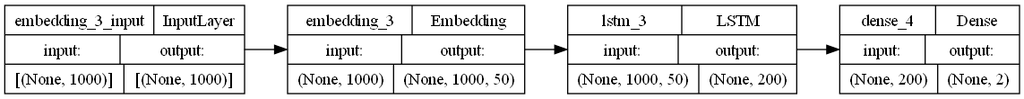

```python
# Plots the graph
utils.plot_model(
    rnn2,
    to_file="model.png",
    show_shapes=True,
    show_layer_names=True,
    rankdir="LR",
    expand_nested=False,
    dpi=96,
)
```

Below, we generate predictions using RNN3 and print the classification report based on the actual test data and predicted data. The y_predict_proba array contains the predicted probabilities for each class, while the y_predict array is the binary predicted output by rounding off these probabilities.

The classification_report function() from scikit-learn is then used to print the precision, recall, and F1-score for both classes (0 and 1), as well as micro, macro, weighted, and samples average scores for the model's overall performance.

In this case, the model achieves an average F1-score of 0.74 for class 0 and 0.77 for class 1. The model achieves an average precision score of 0.79 for class 0 and 0.74 for class 1, and achieves an average recall score of 0.70 for class 0 and 0.81 for class 1.

```python
# Defines the y-prediction probability and y-prediction arrays
y_predict_proba = rnn2.predict(X_test)
y_predict = np.round(y_predict_proba)

clear_screen()

# Prints classification report
print(classification_report(y_test_ohe, y_predict, zero_division=0))
```

```
              precision    recall  f1-score   support

           0       0.79      0.70      0.74       996
           1       0.74      0.81      0.77      1004

   micro avg       0.76      0.76      0.76      2000
   macro avg       0.76      0.76      0.76      2000
weighted avg       0.76      0.76      0.76      2000
 samples avg       0.75      0.76      0.75      2000
```

Below we compute the accuracy of the model's predictions on the test dataset using the accuracy_score() function from the scikit-learn library and then print the result as a percentage with 2 decimal places.

The accuracy is 75%, which means that 75% of the test data instances were classified correctly by the model. RNN3's accuracy score is just below RNN1 (76%), but it also has room for improvement.

```python
acc_3 = mt.accuracy_score(y_test_ohe, y_predict)
print(f"Accuracy: {acc_3 * 100:.2f}%")
```

```
Accuracy: 75.00%
```

Below we generate a loss graph of the training process for RNN3. The loss values are collected from the rnn_history object, which stores the loss values for each epoch during the training process. The code then plots the loss values against the number of epochs using Matplotlib.

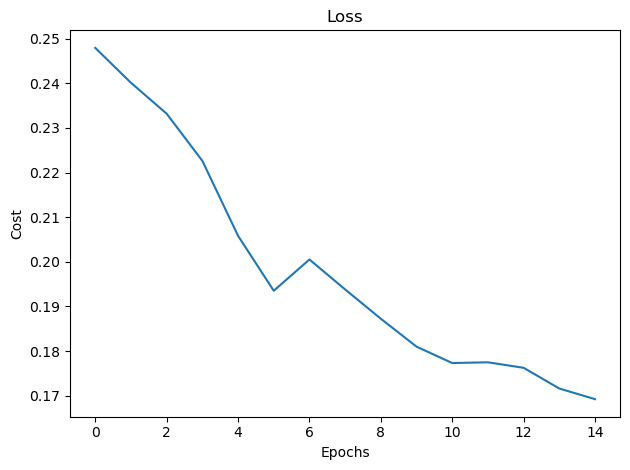

```python
# Variables for determining the loss over epochs
epochs = rnn2_history.epoch
loss = rnn2_history.history["loss"]

# Plots the loss graph
plt.plot(epochs, loss)
plt.ylabel("Cost")
plt.xlabel("Epochs")
plt.title("Loss")

plt.tight_layout()

plt.show()
```

The code below evaluates and visualizes the Receiver Operating Characteristic (ROC) curve and Area Under the Curve (AUC) for RNN3. The ROC curve is a graphical representation of the performance of a binary classification system, showing the trade-off between the true positive rate (TPR) and the false positive rate (FPR) as the decision threshold for classification is varied. The AUC is a metric that summarizes the overall performance of the model, with a higher AUC indicating better performance.

Our AUC for this run is 0.76, exactly like RNN1, indicating that the model has a decent ability t0 distinguish between positive and negative cases. The ROC curve visualizes this by showing a rise in the curve until reaching a point where the TPR is 0.8 and the FPR is 0.3. From there, it gradually increases until reaching the end of the graph indicating that the model is able to identify some positive cases while making errors with some false positive predictions. Overall, this suggests that the RNN model is able to make correct predictions without guessing or randomly choosing a class label, but there is still room for improvement.

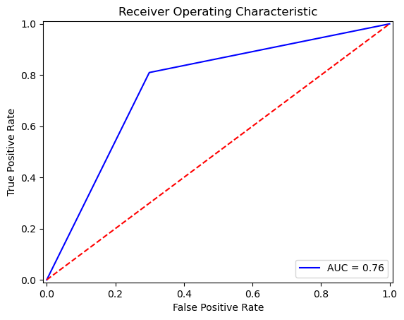

```python
# Variables for determining the ROC/AUC
fpr, tpr, threshold = roc_curve(
    np.argmax(y_test_ohe, axis=1), np.argmax(y_predict_proba, axis=1)
)
roc_auc = auc(fpr, tpr)

# Plots the ROC and AUC graph
plt.title("Receiver Operating Characteristic")
plt.plot(fpr, tpr, "b", label="AUC = %0.2f" % roc_auc)
plt.legend(loc="lower right")
plt.plot([0, 1], [0, 1], "r--")
plt.xlim([-0.01, 1.01])
plt.ylim([-0.01, 1.01])
plt.ylabel("True Positive Rate")
plt.xlabel("False Positive Rate")
plt.show()
```

The code below plots the training versus testing graph for RNN3. The graph has three subplots: the first subplot shows the training and validation loss versus epochs, the second subplot shows the training and validation recall versus epochs, and the third subplot shows the training and validation AUC versus epochs.

The training versus testing graph is used to visualize the performance of the model during training. We can see that the training loss and validation loss decrease as the number of epochs increases. The validation curve shows some strange behavior at from epoch 10 to 11, where the loss value rises, but afterwards continues decreasing. The validation curve has a slightly lower loss value than the training curve, but the overall behavior of the curves show that the model is learning and improving.

The training recall and validation recall also increase as the number of epochs increases, thought they show very erratic behavior. The curves overcome the other curve at multiple points, but the validation curve ultimately comes out with a higher recall score by a slight margin. Regardless, the graph demostrates that the model is becoming better at identifying the sentiment of reviews.

Finally, the training AUC and validation AUC increase as the number of epochs increases, only becoming jagged after epoch 9. Though the training curve has a higher AUC value by the slighest margins, the graph indicates that the model is becoming better at distinguishing between positive and negative sentiment in reviews.

Overall, the graph shows that the RNN model is improving over time, and that it is performing well on both the training and validation sets.

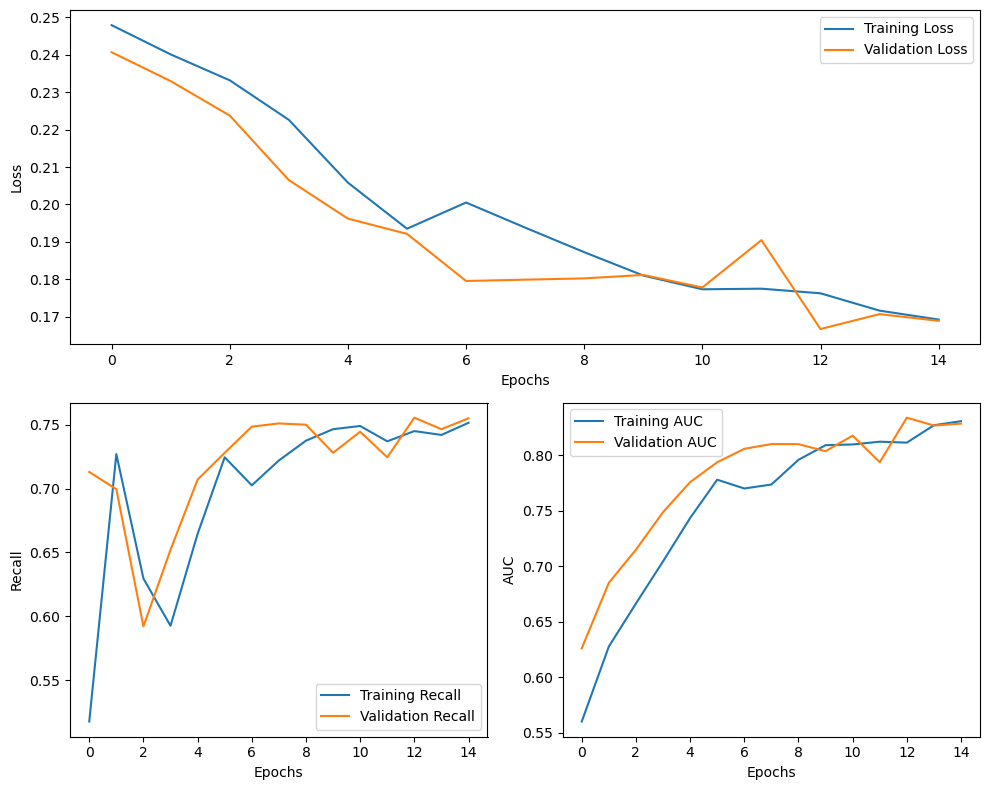

```python
# Model history values
hist_values = list(rnn2_history.history.values())

# Variables for plotting the training versus testing
train_loss   = hist_values[0]
train_recall = hist_values[1]
train_auc    = hist_values[2]
val_loss     = hist_values[3]
val_recall   = hist_values[4]
val_auc      = hist_values[5]

# Plots the training versus testing graph
plt.figure(figsize=(10, 8))
plt.subplot(2, 2, (1, 2))
plt.plot(train_loss, label="Training Loss")
plt.plot(val_loss, label="Validation Loss")
plt.xlabel("Epochs")
plt.ylabel("Loss")
plt.legend()

plt.subplot(2, 2, 3)
plt.plot(train_recall, label="Training Recall")
plt.plot(val_recall, label="Validation Recall")
plt.xlabel("Epochs")
plt.ylabel("Recall")
plt.legend()

plt.subplot(2, 2, 4)
plt.plot(train_auc, label="Training AUC")
plt.plot(val_auc, label="Validation AUC")
plt.xlabel("Epochs")
plt.ylabel("AUC")
plt.legend()

plt.tight_layout()

plt.show()
```

Accuracy is a measure of the overall correctness of a model's predictions, calculated as the ratio of the number of correct predictions to the total number of predictions. For this run, our initial accuracy score is 0.75 or roughly 75%.

Misclass, or misclassification, refers to the instances where a model's prediction does not match the actual class label of a data point. Misclassification can be measured using various metrics such as accuracy, precision, recall, and F1-score - but in this case we can easily determine misclass by calculating 1.0 minus the accuracy score. In our case, we observe the misclass as 0.24 or 24%.

Precision is a measure of how well a model correctly identifies positive instances among the predicted positive instances. Precision is calculated as the ratio of the number of true positive predictions to the total number of positive predictions (which would be the true positive predictions plus the false positive predictions). In our case, the precision score is 0.76 or 76%. It is just above our accuracy value, still making it ideal for finding a viable solution for field-use as it is important to minimize false positives and maximize true positives.

Recall, also known as sensitivity or the true positive rate, is a measure of how well a model identifies all the positive instances among the actual positive instances. Recall is calculated as the ratio of the number of true positive predictions to the total number of actual positive instances (i.e., sum of true positive and false negative predictions). Our recall score for this run was 0.75 or 75% - exactly our accuracy score.

F1-score is the "harmonic mean" of precision and recall, providing a single value that balances the trade-off between precision and recall. It is calculated as 2 *(precision* recall) / (precision + recall). Our F1-score for this run was 0.75 or roughly 75%.

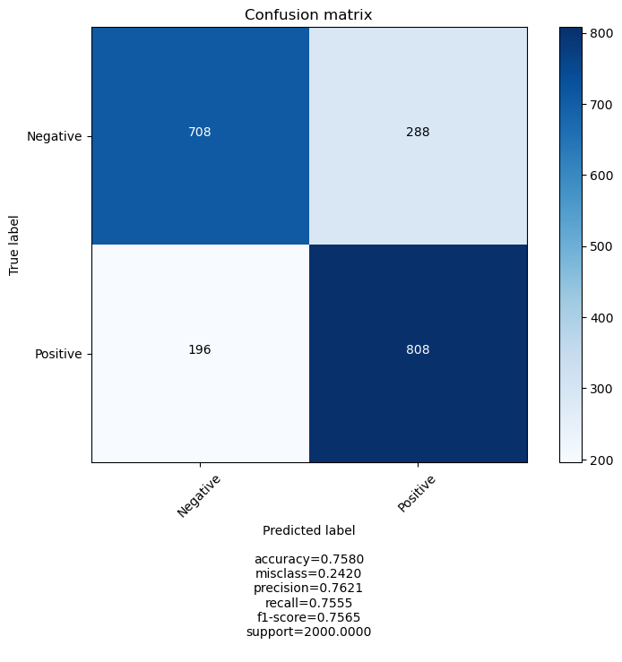

```python
class_report = classification_report(
    y_test_ohe, y_predict, zero_division=0, output_dict=True
)

plot_confusion_matrix(
    confusion_matrix(
        np.argmax(y_test_ohe, axis=1), np.argmax(y_predict, axis=1)
    ),
    [classes[0], classes[1]],
    normalize=False,
    class_results=class_report["weighted avg"],
)
```

Below, we make a prediction using RNN3 on a randomly selected review from the dataset df. The review text and the actual label are displayed, followed by the predicted label.

In this case, both the actual and predicted label are negative - meaning that the model correctly predicted the sentiment for this sample review.

```python
# Observe how the model predicts a review
review_test(rnn2, random.randint(1, 10000), df)
```

**Text:** i whether rent always afraid something never dont remember great cast thats tipped scales i almost stopped watching the first fun watch unbelievable it worse the movie could little research future want make even little better or could try writing something little bit believable i give writing able get many good agree movie despite read script oh god movie

**Actual:** negative

```
1/1 - 1s - 885ms/epoch - 885ms/step
```

**Predicted:** negative

### RNN 4

The given code is a Keras model for a Recurrent Neural Network (RNN) with an Embedding layer, a Gated Recurrent Unit (GRU) layer, and a Dense layer. The model is compiled with the Adamax optimizer, mean squared error (MSE) loss, and uses two metrics: Recall and AUC. The model is then trained on training data X_train and y_train_ohe for 15 epochs and a batch size of 512, and validated using the testing data X_test and y_test_ohe. The summary of the model is displayed using the summary() function of the model.

The output shows a summary of the RNN model with its layers and the number of parameters in each layer. The model has a total of 1,856,852 parameters, out of which 151,602 are trainable, and the remaining 1,705,250 are non-trainable because they belong to the Embedding layer. The model has an Embedding layer that takes input of shape (None, 1000) and outputs a tensor of shape (None, 1000, 50), indicating that the input has 1000 words, and each word is represented by a 50-dimensional vector. The GRU layer takes the output of the Embedding layer as input and produces a tensor of shape (None, 200) as output. Finally, the Dense layer produces a tensor of shape (None, 2) as output, representing the probabilities of the two classes in the binary classification problem.

GRU Statesize = 200

dropout = 0.20

recurrent dropout = 0.20

```python
# create GRU
gru2 = Sequential()
gru2.add(embedding_layer)
gru2.add(GRU(200, dropout=0.20, recurrent_dropout=0.20))
gru2.add(Dense(NUM_CLASSES, activation="sigmoid"))
gru2.compile(
    optimizer="Adamax",
    loss="mse",
    metrics=[keras.metrics.Recall(), keras.metrics.AUC()],
)

gru2_history = gru2.fit(
    X_train,
    y_train_ohe,
    validation_data=(X_test, y_test_ohe),
    epochs=15,
    batch_size=512,
)
clear_screen()

gru2.summary()
```

```
Model: "sequential_5"
_________________________________________________________________
 Layer (type)                Output Shape              Param #
=================================================================
 embedding_3 (Embedding)     (None, 1000, 50)          1705250

 gru_1 (GRU)                 (None, 200)               151200

 dense_5 (Dense)             (None, 2)                 402

=================================================================
Total params: 1,856,852
Trainable params: 151,602
Non-trainable params: 1,705,250
_________________________________________________________________
```

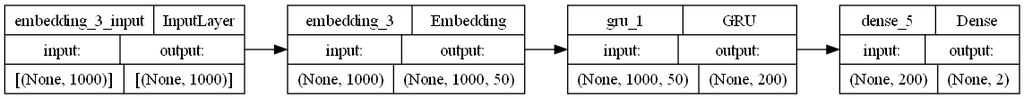

```python
# Plots the graph
utils.plot_model(
    gru2,
    to_file="model.png",
    show_shapes=True,
    show_layer_names=True,
    rankdir="LR",
    expand_nested=False,
    dpi=96,
)
```

Below, we generate predictions using RNN4 and print the classification report based on the actual test data and predicted data. The y_predict_proba array contains the predicted probabilities for each class, while the y_predict array is the binary predicted output by rounding off these probabilities.

The classification_report function() from scikit-learn is then used to print the precision, recall, and F1-score for both classes (0 and 1), as well as micro, macro, weighted, and samples average scores for the model's overall performance.

In this case, the model achieves an average F1-score of 0.75 for class 0 and 0.74 for class 1. The model achieves an average precision score of 0.73 for class 0 and 0.76 for class 1, and achieves an average recall score of 0.77 for class 0 and 0.72 for class 1.

```python
# Defines the y-prediction probability and y-prediction arrays
y_predict_proba = gru2.predict(X_test)
y_predict = np.round(y_predict_proba)

clear_screen()

# Prints classification report
print(classification_report(y_test_ohe, y_predict, zero_division=0))
```

```
              precision    recall  f1-score   support

           0       0.73      0.77      0.75       996
           1       0.76      0.72      0.74      1004

   micro avg       0.74      0.74      0.74      2000
   macro avg       0.75      0.74      0.74      2000
weighted avg       0.75      0.74      0.74      2000
 samples avg       0.74      0.74      0.74      2000
```

Below we compute the accuracy of the model's predictions on the test dataset using the accuracy_score() function from the scikit-learn library and then print the result as a percentage with 2 decimal places.

The accuracy is 73.60%, which means that 73.60% of the test data instances were classified correctly by the model. RNN4 peforms better than RNN2 but performs slightly worse than RNN3 and RNN1.

```python
acc_4 = mt.accuracy_score(y_test_ohe, y_predict)
print(f"Accuracy: {acc_4 * 100:.2f}%")
```

```
Accuracy: 73.60%
```

Below we generate a loss graph of the training process for RNN4. The loss values are collected from the rnn_history object, which stores the loss values for each epoch during the training process. The code then plots the loss values against the number of epochs using Matplotlib.

The output graph shows the decreasing trend of the loss over time. The curve starts with a gradual descent, but then takes on a concave shape from epoch 2 to epoch 10, where the curve crosses higher loss values than if it would've stayed linear. Afterwards, the curve continues declining, changing its slope at epochs 12 and 13 until ending with a loss value of less than 0.18 at epoch 14.

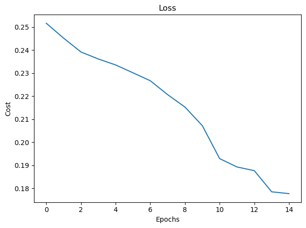

```python
# Variables for determining the loss over epochs
epochs = gru2_history.epoch
loss = gru2_history.history["loss"]

# Plots the loss graph
plt.plot(epochs, loss)
plt.ylabel("Cost")
plt.xlabel("Epochs")
plt.title("Loss")

plt.tight_layout()

plt.show()
```

The code below evaluates and visualizes the Receiver Operating Characteristic (ROC) curve and Area Under the Curve (AUC) for RNN4. The ROC curve is a graphical representation of the performance of a binary classification system, showing the trade-off between the true positive rate (TPR) and the false positive rate (FPR) as the decision threshold for classification is varied. The AUC is a metric that summarizes the overall performance of the model, with a higher AUC indicating better performance.

Our AUC for this run is 0.75 indicating that the model has a decent ability to distinguish between positive and negative cases. The ROC curve visualizes this by showing a rise in the curve until reaching a point where the TPR is 0.75 and the FPR is 0.2. From there, it gradually increases until reaching the end of the graph indicating that the model is able to identify some positive cases while making errors with some false positive predictions. Overall, this suggests that the RNN model is able to make correct predictions without guessing or randomly choosing a class label, but there is still room for improvement.

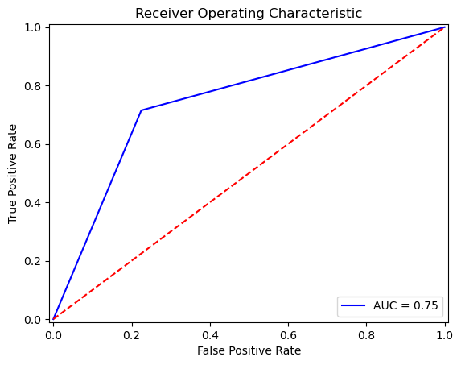

```python
# Variables for determining the ROC/AUC
fpr, tpr, threshold = roc_curve(
    np.argmax(y_test_ohe, axis=1), np.argmax(y_predict_proba, axis=1)
)
roc_auc = auc(fpr, tpr)

# Plots the ROC and AUC graph
plt.title("Receiver Operating Characteristic")
plt.plot(fpr, tpr, "b", label="AUC = %0.2f" % roc_auc)
plt.legend(loc="lower right")
plt.plot([0, 1], [0, 1], "r--")
plt.xlim([-0.01, 1.01])
plt.ylim([-0.01, 1.01])
plt.ylabel("True Positive Rate")
plt.xlabel("False Positive Rate")
plt.show()
```

The code below plots the training versus testing graph for RNN4. The graph has three subplots: the first subplot shows the training and validation loss versus epochs, the second subplot shows the training and validation recall versus epochs, and the third subplot shows the training and validation AUC versus epochs.

The training versus testing graph is used to visualize the performance of the model during training. We can see that the training loss and validation loss decrease at a stable rate as the number of epochs increases, and since the training curve has higher loss values than the validation curve, the graph indicates that the model is learning and improving.

The training recall and validation recall also increase with some erratic behavior as the number of epochs increases. The curves overcome the other curve at 3 points, but the validation curve comes out with a higher recall score by a small margin. Regardless, the graph demostrates that the model is becoming better at identifying the sentiment of reviews.

Finally, the training AUC and validation AUC increase as the number of epochs increases, and with the validation curve having higher values than the training curve by a good margin, the graph indicates that the model is becoming better at distinguishing between positive and negative sentiment in reviews.

Overall, the graph shows that the RNN model is improving over time, and that it is performing well on both the training and validation sets.

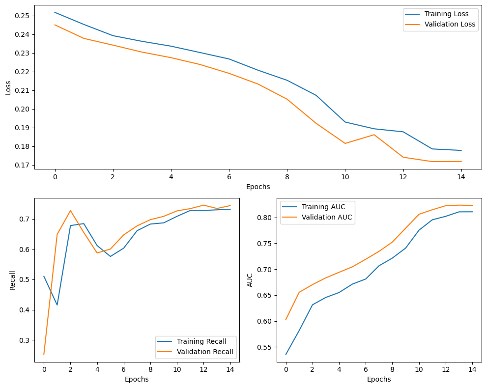

```python
# Model history values
hist_values = list(gru2_history.history.values())

# Variables for plotting the training versus testing
train_loss   = hist_values[0]
train_recall = hist_values[1]
train_auc    = hist_values[2]
val_loss     = hist_values[3]
val_recall   = hist_values[4]
val_auc      = hist_values[5]

# Plots the training versus testing graph
plt.figure(figsize=(10, 8))
plt.subplot(2, 2, (1, 2))
plt.plot(train_loss, label="Training Loss")
plt.plot(val_loss, label="Validation Loss")
plt.xlabel("Epochs")
plt.ylabel("Loss")
plt.legend()

plt.subplot(2, 2, 3)
plt.plot(train_recall, label="Training Recall")
plt.plot(val_recall, label="Validation Recall")
plt.xlabel("Epochs")
plt.ylabel("Recall")
plt.legend()

plt.subplot(2, 2, 4)
plt.plot(train_auc, label="Training AUC")
plt.plot(val_auc, label="Validation AUC")
plt.xlabel("Epochs")
plt.ylabel("AUC")
plt.legend()

plt.tight_layout()

plt.show()
```

Accuracy is a measure of the overall correctness of a model's predictions, calculated as the ratio of the number of correct predictions to the total number of predictions. For this run, our initial accuracy score is 0.74 or roughly 74%.

Misclass, or misclassification, refers to the instances where a model's prediction does not match the actual class label of a data point. Misclassification can be measured using various metrics such as accuracy, precision, recall, and F1-score - but in this case we can easily determine misclass by calculating 1.0 minus the accuracy score. In our case, we observe the misclass as 0.25 or 25%.

Precision is a measure of how well a model correctly identifies positive instances among the predicted positive instances. Precision is calculated as the ratio of the number of true positive predictions to the total number of positive predictions (which would be the true positive predictions plus the false positive predictions). In our case, the precision score is 0.74 or 74%. It is the same as our accuracy value which we feel is ideal for finding a viable solution for field-use as it is important to minimize false positives and maximize true positives.

Recall, also known as sensitivity or the true positive rate, is a measure of how well a model identifies all the positive instances among the actual positive instances. Recall is calculated as the ratio of the number of true positive predictions to the total number of actual positive instances (i.e., sum of true positive and false negative predictions). Our recall score for this run was 0.74 or 74% - exactly our accuracy score.

F1-score is the "harmonic mean" of precision and recall, providing a single value that balances the trade-off between precision and recall. It is calculated as 2 *(precision* recall) / (precision + recall). Our F1-score for this run was 0.74 or roughly 74%.

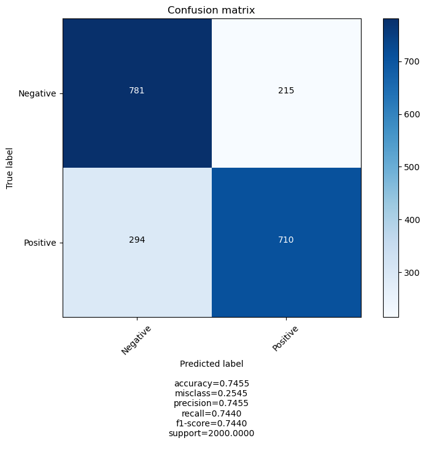

```python
class_report = classification_report(
    y_test_ohe, y_predict, zero_division=0, output_dict=True
)

plot_confusion_matrix(
    confusion_matrix(
        np.argmax(y_test_ohe, axis=1), np.argmax(y_predict, axis=1)
    ),
    [classes[0], classes[1]],
    normalize=False,
    class_results=class_report["weighted avg"],
)
```

Below, we make a prediction using RNN4 on a randomly selected review from the dataset df. The review text and the actual label are displayed, followed by the predicted label.

In this case, both the actual and predicted label are negative - meaning that the model correctly predicted the sentiment for this sample review.

```python
# Observe how the model predicts a review
review_test(gru2, random.randint(1, 10000), df)
```

**Text:** this bad movie there much id like tommy lee jones good possible script gave couple decent action felt really place due acceptable quality somewhere along line someone figured script could hire every single actor business unfortunately even truly deeply talented like goodman gammon taylor vince lest forget mr jones cant fix wooden dialogue plot progression went absolutely nowhere in fact one point i sure movie running past find i perhaps painful point movie subplot ghost confederate seem little help story other slightly business end picture havent seen movie disregard past statement may seem know understand better watched movie the interesting thing movie may actually sequel movie heavens starring alec baldwin role carried tommy lee jones movie i may watch first see bad in electric mist second i cant seem matter hard i try break man crush alec baldwin

**Actual:** negative

```
2/2 - 2s - 2s/epoch - 959ms/step
```

**Predicted:** negative

### Model Comparison

The code below outputs a bar chart of each model's accuracy for comparison.

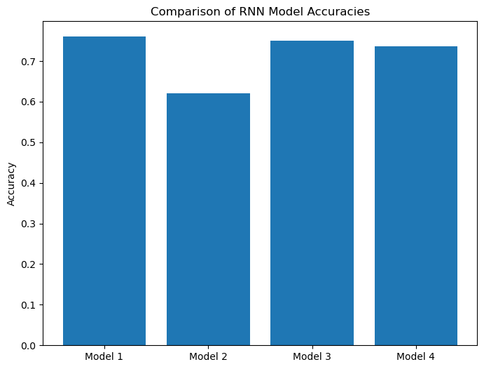

```python
accuracies = [acc_1, acc_2, acc_3, acc_4]

fig = plt.figure(figsize=[8, 6])
plt.bar([1, 2, 3, 4], accuracies)
plt.xticks([1, 2, 3, 4], [f"model {i}".title() for i in range(1, 5)])
plt.ylabel("Accuracy")
plt.title("Comparison of RNN Model Accuracies")
plt.show()
```

### Adding a Second Recurrent Chain

✅ Using the best parameters and architecture from the RNN in the previous step, add a second recurrent chain to your RNN. The input to the second chain should be the output sequence of the first chain. Visualize the performance of training and validation sets versus the training iterations.

Since RNN1 and RNN3 were our best performing models, and the models were implemented with an LSTM architecture, our RNN5 model with also be implemented with the same architecture, and we will use the parameters of RNN3 for RNN5.

The dropout parameter of the LSTM layer states a fraction of the units that will be dropped for the linear transformation of the inputs. By changing the value from 0.3 to 0.25, we will include more units for the linear transformation of the inputs, which could have some impact in how the model reads in the inputs and its peformance on the testing dataset.

The recurrent_dropout parameter of the LSTM layer states a fraction of the units that will be dropped for the linear transformation of the recurrent state. By changing the value from 0.3 to 0.25, we will include more units for the linear transformation of recurrent state, which could have some impact on its peformance with the testing dataset.

The batch size of can greatly affect the performance of a model. In reducing the batch size by half, the model is less likely to be stuck in local minima and find the global minima, ultimately increasing the performance of the model.

```python
rnn5 = Sequential()
rnn5.add(embedding_layer)
rnn5.add(LSTM(200, return_sequences=True, dropout=0.25, recurrent_dropout=0.25))
rnn5.add(LSTM(100, dropout=0.2, recurrent_dropout=0.2))
rnn5.add(Dense(NUM_CLASSES, activation="sigmoid"))
rnn5.compile(
    optimizer="Adamax",
    loss="mse",
    metrics=[keras.metrics.Recall(), keras.metrics.AUC()],
)
rnn5_history = rnn5.fit(
    X_train,
    y_train_ohe,
    validation_data=(X_test, y_test_ohe),
    epochs=EPOCHS,
    batch_size=256,
)
clear_screen()

rnn5.summary()
```

```
Model: "sequential_6"
_________________________________________________________________
 Layer (type)                Output Shape              Param #
=================================================================
 embedding_3 (Embedding)     (None, 1000, 50)          1705250

 lstm_4 (LSTM)               (None, 1000, 200)         200800

 lstm_5 (LSTM)               (None, 100)               120400

 dense_6 (Dense)             (None, 2)                 202

=================================================================
Total params: 2,026,652
Trainable params: 321,402
Non-trainable params: 1,705,250
_________________________________________________________________
```

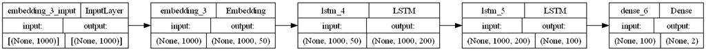

```python
# you will need to install pydot properly on your machine to get this running
plot_model(
    rnn5, to_file='model.png', show_shapes=True, show_layer_names=True,
    rankdir='LR', expand_nested=False, dpi=96
)
```

The classification_report() function from scikit-learn is then used to print the precision, recall, and F1-score for both classes (0 and 1), as well as micro, macro, weighted, and samples average scores for the model's overall performance.

```python
# Defines the y-prediction probability and y-prediction arrays
y_predict_proba = rnn.predict(X_test)
y_predict = np.round(y_predict_proba)

clear_screen()

# Prints classification report
print(classification_report(y_test_ohe, y_predict, zero_division=0))
```

```
              precision    recall  f1-score   support

           0       0.76      0.75      0.76       996
           1       0.76      0.77      0.76      1004

   micro avg       0.76      0.76      0.76      2000
   macro avg       0.76      0.76      0.76      2000
weighted avg       0.76      0.76      0.76      2000
 samples avg       0.76      0.76      0.76      2000
```

Below we compute the accuracy of the model's predictions on the test dataset using the accuracy_score() function from the scikit-learn library and then print the result as a percentage with 2 decimal places.

```python
acc_5 = mt.accuracy_score(y_test_ohe, y_predict)
print(f"Accuracy: {acc_5 * 100:.2f}%")
```

```
Accuracy: 76.00%
```

Below we generate a loss graph of the training process for RNN5. The loss values are collected from the rnn_history object, which stores the loss values for each epoch during the training process. The code then plots the loss values against the number of epochs using Matplotlib.

The output graph shows the decreasing trend of the loss over time, starting with a linear slope from epoch 0 to 3. The curve's slope becomes more gradual afterwards, starying almost flat from epoch 9 to 11, before slightly rising to a higher loss value. At epoch 13, the loss value decreases until ending with a loss value of less than 0.16 at epoch 14.

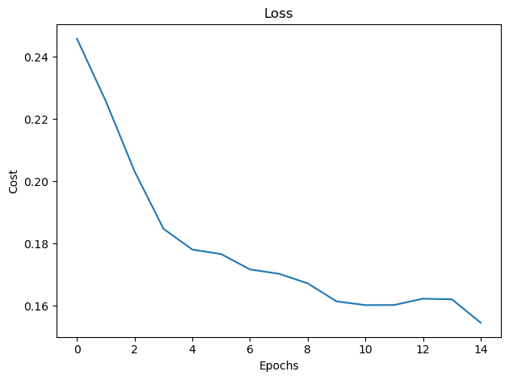

```python
# Variables for determining the loss over epochs
epochs = rnn5_history.epoch
loss = rnn5_history.history["loss"]

# Plots the loss graph
plt.plot(epochs, loss)
plt.ylabel("Cost")
plt.xlabel("Epochs")
plt.title("Loss")

plt.tight_layout()

plt.show()
```

The code below evaluates and visualizes the Receiver Operating Characteristic (ROC) curve and Area Under the Curve (AUC) for RNN5. The ROC curve is a graphical representation of the performance of a binary classification system, showing the trade-off between the true positive rate (TPR) and the false positive rate (FPR) as the decision threshold for classification is varied. The AUC is a metric that summarizes the overall performance of the model, with a higher AUC indicating better performance.

Our AUC for this run is 0.76 indicating that the model has a decent ability to distinguish between positive and negative cases. The ROC curve visualizes this by showing a rise in the curve until reaching a point where the TPR is 0.8 and the FPR is 0.2. From there, it gradually increases until reaching the end of the graph indicating that the model is able to identify some positive cases while making errors with some false positive predictions. Overall, this suggests that the RNN model is able to make correct predictions without guessing or randomly choosing a class label, but there is still room for improvement.

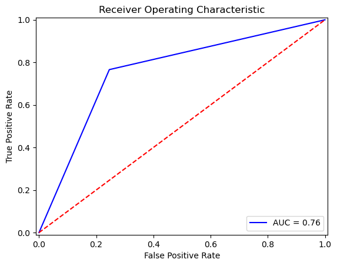

```python
# Variables for determining the ROC/AUC
fpr, tpr, threshold = roc_curve(
    np.argmax(y_test_ohe, axis=1), np.argmax(y_predict_proba, axis=1)
)
roc_auc = auc(fpr, tpr)

# Plots the ROC and AUC graph
plt.title("Receiver Operating Characteristic")
plt.plot(fpr, tpr, "b", label="AUC = %0.2f" % roc_auc)
plt.legend(loc="lower right")
plt.plot([0, 1], [0, 1], "r--")
plt.xlim([-0.01, 1.01])
plt.ylim([-0.01, 1.01])
plt.ylabel("True Positive Rate")
plt.xlabel("False Positive Rate")
plt.show()
```

✅ Use the method of train/test splitting and evaluation criteria that you argued for at the beginning of the lab.

The code below plots the training versus testing graph for RNN5. The graph has three subplots: the first subplot shows the training and validation loss versus epochs, the second subplot shows the training and validation recall versus epochs, and the third subplot shows the training and validation AUC versus epochs.

The training versus testing graph is used to visualize the performance of the model during training. We can see that the training loss and validation loss decrease as the number of epochs increases. The validation curve shows some strange behavior at from epoch 8 to 12, where the loss value rises, but afterwards continues decreasing, having a higher loss value than the training curve. Regardless, the model is learning and improving.

Finally, the training AUC and validation AUC increase as the number of epochs increases, only becoming jagged after epoch 9. Though the training curve has a higher AUC value by the slighest margins, the graph indicates that the model is becoming better at distinguishing between positive and negative sentiment in reviews.

Overall, the graph shows that the RNN model is improving over time, and that it is performing well on both the training and validation sets.

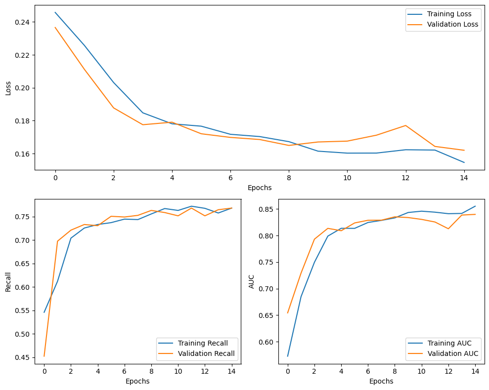

```python
# Model history values
hist_values = list(rnn5_history.history.values())

# Variables for plotting the training versus testing
train_loss   = hist_values[0]
train_recall = hist_values[1]
train_auc    = hist_values[2]
val_loss     = hist_values[3]
val_recall   = hist_values[4]
val_auc      = hist_values[5]

# Plots the training versus testing graph
plt.figure(figsize=(10, 8))
plt.subplot(2, 2, (1, 2))
plt.plot(train_loss, label="Training Loss")
plt.plot(val_loss, label="Validation Loss")
plt.xlabel("Epochs")
plt.ylabel("Loss")
plt.legend()

plt.subplot(2, 2, 3)
plt.plot(train_recall, label="Training Recall")
plt.plot(val_recall, label="Validation Recall")
plt.xlabel("Epochs")
plt.ylabel("Recall")
plt.legend()

plt.subplot(2, 2, 4)
plt.plot(train_auc, label="Training AUC")
plt.plot(val_auc, label="Validation AUC")
plt.xlabel("Epochs")
plt.ylabel("AUC")
plt.legend()

plt.tight_layout()

plt.show()
```

Accuracy is a measure of the overall correctness of a model's predictions, calculated as the ratio of the number of correct predictions to the total number of predictions. For this run, our initial accuracy score is 0.76 or roughly 76%.

Misclass, or misclassification, refers to the instances where a model's prediction does not match the actual class label of a data point. Misclassification can be measured using various metrics such as accuracy, precision, recall, and F1-score - but in this case we can easily determine misclass by calculating 1.0 minus the accuracy score. In our case, we observe the misclass as 0.24 or 24%.

Precision is a measure of how well a model correctly identifies positive instances among the predicted positive instances. Precision is calculated as the ratio of the number of true positive predictions to the total number of positive predictions (which would be the true positive predictions plus the false positive predictions). In our case, the precision score is 0.76 or 76%. It is the same as our accuracy value which we feel is ideal for finding a viable solution for field-use as it is important to minimize false positives and maximize true positives.

Recall, also known as sensitivity or the true positive rate, is a measure of how well a model identifies all the positive instances among the actual positive instances. Recall is calculated as the ratio of the number of true positive predictions to the total number of actual positive instances (i.e., sum of true positive and false negative predictions). Our recall score for this run was 0.76 or 76% - exactly our accuracy score.

F1-score is the "harmonic mean" of precision and recall, providing a single value that balances the trade-off between precision and recall. It is calculated as 2 *(precision* recall) / (precision + recall). Our F1-score for this run was 0.76 or roughly 76%.

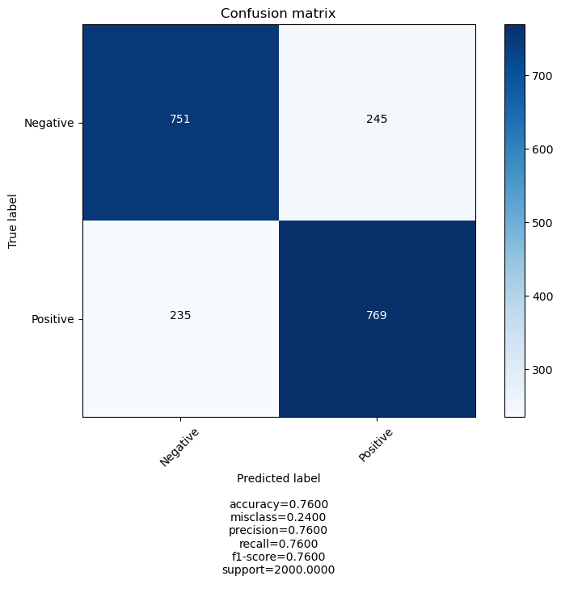

```python
class_report = classification_report(
    y_test_ohe, y_predict, zero_division=0, output_dict=True
)

plot_confusion_matrix(
    confusion_matrix(
        np.argmax(y_test_ohe, axis=1), np.argmax(y_predict, axis=1)
    ),
    [classes[0], classes[1]],
    normalize=False,
    class_results=class_report["weighted avg"],
)
```

Below, we make a prediction using RNN5 on a randomly selected review from the dataset df. The review text and the actual label are displayed, followed by the predicted label.

In this case, both the actual and predicted label are negative - meaning that the model correctly predicted the sentiment for this sample review.

```python
# Observe how the model predicts a review
review_test(rnn5, random.randint(1, 10000), df)
```

**Text:** this unrealistic movie i ever seen i cant believe writer director didnt see almost movie like one for example it impossible killer stay cold glaze get quickly you cant get trough water pipe like movie believe domain with saw cut hour easy say chain made steel water pipe rusty made iron if try cut foot saw faint best case likely die hart get and

**Actual:** negative

```
1/1 - 2s - 2s/epoch - 2s/step
```

**Predicted:** negative

### Model Comparison with Second Recurrent Chain Model (RNN5)

✅ Visualize the results of all the RNNs you trained.

The code below outputs a bar chart of each model's accuracy for comparison.

One reason why we do not see an improvement in RNN5 compared to RNN1 - despite the decreased batch size - could be because adding more layers increased the risk of overfitting for our model. Another possibility is that adding more layers to the model increases the difficulty in finding the optimal set of hyperparameters to use.

The models may also not be directly comparable, as they have different architectures (RNN1 has only one LSTM layer, while RNN5 has two LSTM layers with different sizes and return_sequences=True). Therefore, even if the change in batch size had an effect, it may have been masked by the differences in the models' architecture.

Additionally, the models may have already reached their optimal performance and further tuning may not lead to significant improvements. If the models have already learned all the relevant patterns in the data, changing the batch size may not lead to significant improvements in performance.

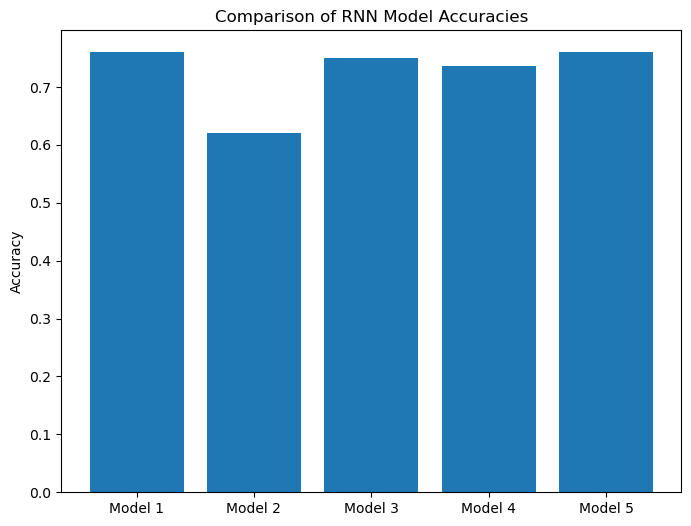

```python
accuracies = [acc_1, acc_2, acc_3, acc_4, acc_5]

fig = plt.figure(figsize=[8, 6])
plt.bar([1, 2, 3, 4, 5], accuracies)
plt.xticks([1, 2, 3, 4, 5], [f"model {i}".title() for i in range(1, 6)])
plt.ylabel("Accuracy")
plt.title("Comparison of RNN Model Accuracies")
plt.show()
```